# Evaluating the Role of Airbnb in Zurich’s Neighbourhoods

Ana Mas Urquijo, Azeglio Martinelli

2026-02-18

# 1 Introduction

Zurich is widely recognised as one of the most constrained housing markets in Switzerland. Strong population growth, limited land availability, and a persistently low vacancy rate have made access to long-term rental housing increasingly difficult. For many residents, the process of finding an apartment involves long waiting lists and crowded viewings, reflecting the intense competition for available housing. Ensuring sufficient long-term housing supply has therefore become a key policy challenge for the city.

At the same time, short-term rental platforms such as Airbnb have expanded significantly in Zurich over the past decade. These platforms offer flexible accommodation options for tourists and business travellers and can provide additional income opportunities for residents. However, when residential units are offered frequently or on a year-round basis as short-term rentals, they may reduce the availability of housing for long-term residents. This potential trade-off between tourism demand and housing supply has sparked increasing public debate.

In response to similar challenges, several Swiss cities and cantons have introduced regulatory measures aimed at limiting the intensity of short-term rentals. One commonly discussed instrument is a cap on the number of nights per year that a dwelling may be rented to tourists, such as a limit of 90 nights annually. The City of Zurich is currently considering whether comparable regulations would be appropriate and how such measures could be implemented in a targeted and proportionate way.

Importantly, the role of Airbnb is unlikely to be uniform across the city. In some neighbourhoods, short-term rentals may complement existing accommodation infrastructure, particularly where hotel capacity is limited. In other areas, a high concentration of listings or hosts managing multiple properties may indicate a more commercial use of residential housing. At the same time, guest reviews and booking activity provide insight into whether Airbnb listings deliver positive experiences for visitors, which is a relevant consideration for tourism policy.

This analysis is conducted for a hypothetical client, the City of Zurich, with the objective of evaluating the role of Airbnb across Zurich neighbourhoods. Using publicly available data, the study examines spatial patterns of listings, host concentration, rental intensity, and guest experiences. The overarching goal is to assess where short-term rentals appear to complement the city’s housing and tourism landscape and where targeted regulatory measures may be justified.

## 1.1 Objectives and Research Questions

The main objective of this analysis is to support the City of Zurich in evaluating whether, and where, regulatory measures on short-term rentals may be appropriate. Rather than treating Airbnb as a uniform phenomenon, the analysis focuses on neighbourhood-level differences and host behaviour.

Specifically, the study addresses the following research questions:

**RQ1:** How are Airbnb listings distributed across Zurich neighbourhoods, and which areas show the highest concentration of short-term rentals?

**RQ2:** Are Airbnb listings more prevalent in certain neighbourhoods, suggesting that short-term rentals may complement local accommodation needs rather than displace long-term housing?

**RQ3:** To what extent is Airbnb activity in Zurich driven by a small number of hosts offering multiple listings, indicating a more commercial use of residential properties?

**RQ4:** Which neighbourhoods exhibit high short-term rental intensity, as reflected by listing availability throughout the year and minimum stay requirements?

**RQ5:** Do guest reviews suggest that Airbnb listings in Zurich provide positive tourist experiences, and does this vary across neighbourhoods or host types?

**RQ6:** Based on listing concentration, host behaviour, and usage intensity, which neighbourhoods would be most affected by potential regulatory measures on short-term rentals?

Together, these questions provide a structured framework for assessing the role of Airbnb in Zurich and for identifying areas where targeted regulation may be most relevant.

# 2 Dataset

## 2.1 Data Sources

The analysis is based on publicly available data from **Inside Airbnb** (https://insideairbnb.com/get-the-data/), an independent, non-commercial project that provides detailed information on Airbnb listings in cities around the world. The platform compiles data directly from Airbnb’s website and aims to support research and policy discussions around short-term rentals.

Two datasets for the city of Zurich are used in this study:

1. **Listings dataset** This dataset contains detailed information on individual Airbnb listings, including their location, room type, price, availability, minimum stay requirements, and host characteristics. It also includes variables such as the number of listings per host and whether a listing is associated with a license.
2. **Reviews dataset** This dataset contains information on guest reviews, including review dates and the number of reviews over time. It allows for an assessment of demand dynamics and guest experiences across listings and neighbourhoods.

The two datasets are merged using the unique listing identifier. This combined dataset enables a joint analysis of spatial distribution, host behaviour, usage intensity, and guest feedback. All data preparation steps, including cleaning and merging, are documented and highlighted in the analysis to ensure full reproducibility.

## 2.2 Data Preparation and Transformations

### 2.2.1 Importing and Inspecting the data

**Unpacking**: The cell below was run only once to unpack the reviews data from a .gz compressed folder. The code cell unpacked the data and directly deleted the compressed files.

```r
library(R.utils)
gunzip("Data/reviews.csv.gz")
```

First, the listings and reviews datasets are imported from CSV files using read_csv and stored as d.listings and d.reviews. Let us import the csvs and get an overview of how the datasets look like to get a first impression. For this we start importing and using the glimpse function of the dplyr package as the head and str functions of base R do not make it that clean.

```r
d.listings <- read_csv("Data/listings.csv")
glimpse(d.listings)
```

```
## Rows: 3,417
## Columns: 18
## $ id                             <dbl> 73282, 143821, 178448, 227039, 283737, …
## $ name                           <chr> "Clean, central, quiet", "LOFT on 2 flo…
## $ host_id                        <dbl> 377532, 697307, 854016, 1184427, 147777…
## $ host_name                      <chr> "Simona", "Erhan", "Delphine", "Lucas",…
## $ neighbourhood_group            <chr> "Kreis 3", "Kreis 3", "Kreis 2", "Kreis…
## $ neighbourhood                  <chr> "Sihlfeld", "Alt-Wiedikon", "Enge", "Es…
## $ latitude                       <dbl> 47.37167, 47.35761, 47.36514, 47.38942,…
## $ longitude                      <dbl> 8.519480, 8.521310, 8.526150, 8.518810,…
## $ room_type                      <chr> "Entire home/apt", "Entire home/apt", "…
## $ price                          <dbl> NA, 232, 48, 501, 160, NA, 360, 238, 22…
## $ minimum_nights                 <dbl> 1125, 3, 5, 4, 4, 5, 7, 5, 5, 3, 3, 3, …
## $ number_of_reviews              <dbl> 47, 0, 9, 31, 383, 11, 13, 7, 162, 25, …
## $ last_review                    <date> 2019-04-27, NA, 2016-05-10, 2023-08-22…
## $ reviews_per_month              <dbl> 0.29, NA, 0.05, 0.18, 2.30, 0.12, 0.08,…
## $ calculated_host_listings_count <dbl> 1, 1, 1, 1, 3, 1, 1, 1, 2, 5, 5, 5, 1, …
## $ availability_365               <dbl> 358, 269, 92, 280, 13, 0, 28, 232, 311,…
## $ number_of_reviews_ltm          <dbl> 0, 0, 0, 0, 21, 0, 0, 0, 15, 0, 0, 0, 2…
## $ license                        <lgl> NA, NA, NA, NA, NA, NA, NA, NA, NA, NA,…
```

**Data Type Transformations** The first impression tells us, that the license columnn might completely be empty. Furthermore, we see that we have: - : Double types, which are numeric values with decimals for continuous numbers. - : Character type, which are text values (strings). - : Date type, which is stored in a specific date format. - :Logical type, storing TRUE or FALSE values

We convert the variables room_type, neighbourhood, and neighbourhood_group to factors because they represent categorical rather than numerical information. This ensures they are treated as discrete groups in the analysis and allows the model to estimate category-specific effects appropriately.

The variables id and host_id are converted to character because they serve as unique identifiers and do not carry numerical meaning.

**Missing Data** After converting the required types, the amount of missing data is examined by - calculating the absolute number of missing values in each column - visualizing the proportion of missing values relative to the total number of observations - visualizing the missing patterns to understand if missing data is systematic

This provides an overview of data completeness and helps identify variables that may require cleaning or removal.

```r
# Convert ids to characters and neighbourhoods and roomtype to factors
d.listings <- d.listings %>%
  mutate(
    id = as.character(id),
    host_id = as.character(host_id),
    neighbourhood_group = factor(neighbourhood_group),
    room_type = factor(room_type),
    neighbourhood = factor(neighbourhood)
  )

# missing data in each column
d.listings %>%
  summarise(across(everything(), ~ sum(is.na(.x)))) %>%
  pivot_longer(everything(),
               names_to = "variable",
               values_to = "n_missing") %>%
  filter(n_missing > 0) %>%          # keeps only variables with missing values
  arrange(desc(n_missing))
```

```
## # A tibble: 4 × 2
##   variable          n_missing
##   <chr>                 <int>
## 1 license                3417
## 2 last_review             834
## 3 reviews_per_month       834
## 4 price                   825
```

Based on this inspection, the column license will be removed from the listings dataset, as our assumption that it only contained missing values was correct. For reviews_per_month and last_review the same amount of observations are missing, which makes us assume, that these will probably be from the same airbnbs, that probably never had a review at all. The missing price is also close to the reviews missing. But lets look at how much % these missing observations actually are:

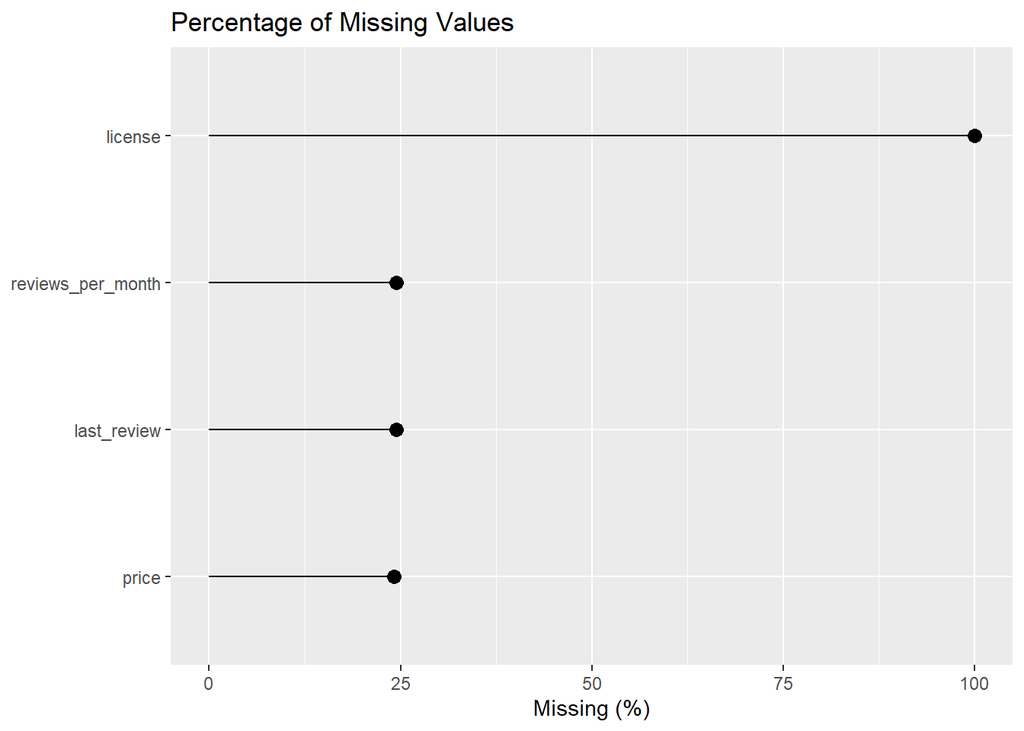

```r
d.listings %>%
  summarise(across(everything(), ~ mean(is.na(.x)))) %>%
  pivot_longer(everything(),
               names_to = "variable",
               values_to = "pct_missing") %>%
  mutate(pct_missing = pct_missing * 100) %>%
  filter(pct_missing > 0) %>%
  ggplot(aes(x = pct_missing,
             y = reorder(variable, pct_missing))) +
  geom_segment(aes(x = 0, xend = pct_missing,
                   yend = variable)) +
  geom_point(size = 3) +
  labs(title = "Percentage of Missing Values",
       x = "Missing (%)",
       y = NULL)
```

The percentages are quite notable, for the 3 almost 25%. But are the observations of price missing the same as for the other 2? Let’s check for this the missing pattern visualization and also to see, if the data is missing systematically.

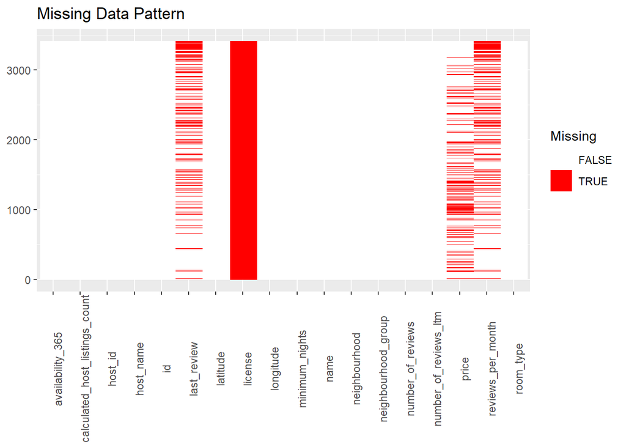

```r
d.listings %>%
  mutate(row_id = row_number()) %>%
  pivot_longer(
    -row_id,
    names_to = "variable",
    values_to = "value",
    values_transform = list(value = as.character)   # 🔥 fix here
  ) %>%
  mutate(is_missing = is.na(value)) %>%
  ggplot(aes(x = variable, y = row_id, fill = is_missing)) +
  geom_raster() +
  scale_fill_manual(values = c("FALSE" = "white",
                               "TRUE"  = "red")) +
  labs(title = "Missing Data Pattern",
       x = NULL,
       y = NULL,
       fill = "Missing") +
  theme(axis.text.x = element_text(angle = 90))
```

The visualization clearly shows, that the missing price observations are mostly not the same airbnbs as the ones that did not have reviews.

While we will replace the missing values of reviews per month variables with zero, we will delete all the airbnbs with price 0, as throughout the analysis, the price is one of the most important aspects and furthermore the fact of not having a price probably means that the airbnb was actually either not available or not on rent at the moment. The last_review variable is intentionally left unchanged, as imputing a date where none exists would not be meaningful.

Finally, the listings dataset is checked for duplicate listing identifiers. This is done by counting how often each id appears, filtering for those that occur more than once, and displaying only the distinct duplicated entries. This step verifies whether the primary key in the listings data is unique, which is important for reliable joins and further analysis.

There are no duplicate listing identifiers.

Now let us import and inspect the reviews.csv.

```r
d.reviews <- read_csv("Data/reviews.csv")
glimpse(d.reviews)
```

```
## Rows: 109,592
## Columns: 6
## $ listing_id    <dbl> 73282, 73282, 73282, 73282, 73282, 73282, 73282, 73282, …
## $ id            <dbl> 1304820, 1448861, 1574534, 1745571, 2026650, 2185724, 22…
## $ date          <date> 2012-05-19, 2012-06-10, 2012-06-27, 2012-07-19, 2012-08…
## $ reviewer_id   <dbl> 1787723, 2183393, 2343568, 2343192, 2092762, 3386921, 39…
## $ reviewer_name <chr> "Jeff", "Rick", "Joseph", "Yvonne", "Joy", "Petru", "Mar…
## $ comments      <chr> "Simona was an excellent hostess. The apartment is beaut…
```

First, the ids are also converted from double to character and we check for missing values.

There are only 4 missing values in the comments column, these are replaced with the string “Unknown” so that all review records contain a valid text entry and can be processed consistently. Afterwards, all non-English comments are deleted, which represent 28.2% of the total comments. It is explained in the next section why this was done.

After cleaning the 2 datasets separately, we can continue to merged them.

First, a join condition is explicitly defined to link the two datasets by matching the id column in the listings data with the listing_id column in the reviews data. Using this condition, the cleaned listings dataset is merged with the reviews dataset using a left join, ensuring that all listings are retained in the merged dataset while review information is added where a matching review exists.

After performing the merge, sanity checks are carried out to assess whether the join behaved as expected. The total number of rows in the merged dataset is computed and compared with the number of rows in the listings data. In addition, the number of unmatched rows is calculated by counting how many entries have missing values in the review identifier column, indicating listings for which no corresponding review record was found.

```r
by <- join_by(id == listing_id)

d.merged <- d.listings %>%
  left_join(d.reviews_eng, by = by)

# Sanity checks for merge below

# Check number of matches where join columns of reviews are NA
d.merged %>%
  summarise(
    total = n(),
    unmatched = sum(is.na(id.y))
  )
```

```
## # A tibble: 1 × 2
##   total unmatched
##   <int>     <int>
## 1 70062       719
```

To further investigate unmatched cases, an anti-join is performed between the listings and reviews datasets. This operation returns only those listings that do not have a matching review. The result is inspected manually using the View() function, allowing a detailed examination of all columns. This inspection confirms that the unmatched entries correspond to listings without any reviews, which explains the absence of a matching listing_id in the reviews data, particularly given that the last_review field contains only missing values for these cases.

Finally, to improve clarity and avoid ambiguity in the merged dataset, review-related columns are renamed. The review identifier column originating from the reviews table is renamed to review_id, and the review date column is renamed to review_date, making the structure and meaning of the merged data clearer for subsequent analysis.

```r
# anti_join to inspect any mismatches
anti_join(d.listings, d.reviews, by = c("id" = "listing_id")) |>
  View()

# rename different review columns
d.merged <- d.merged %>%
  rename(review_id = id.y, review_date = date)
glimpse(d.merged)
```

```
## Rows: 70,062
## Columns: 22
## $ id                             <chr> "143821", "178448", "178448", "178448",…
## $ name                           <chr> "LOFT on 2 floors in Sihlcity Zürich", …
## $ host_id                        <chr> "697307", "854016", "854016", "854016",…
## $ host_name                      <chr> "Erhan", "Delphine", "Delphine", "Delph…
## $ neighbourhood_group            <fct> Kreis 3, Kreis 2, Kreis 2, Kreis 2, Kre…
## $ neighbourhood                  <fct> Alt-Wiedikon, Enge, Enge, Enge, Enge, E…
## $ latitude                       <dbl> 47.35761, 47.36514, 47.36514, 47.36514,…
## $ longitude                      <dbl> 8.52131, 8.52615, 8.52615, 8.52615, 8.5…
## $ room_type                      <fct> Entire home/apt, Private room, Private …
## $ price                          <dbl> 232, 48, 48, 48, 48, 48, 48, 48, 501, 5…
## $ minimum_nights                 <dbl> 3, 5, 5, 5, 5, 5, 5, 5, 4, 4, 4, 4, 4, …
## $ number_of_reviews              <dbl> 0, 9, 9, 9, 9, 9, 9, 9, 31, 31, 31, 31,…
## $ last_review                    <date> NA, 2016-05-10, 2016-05-10, 2016-05-10…
## $ reviews_per_month              <dbl> 0.00, 0.05, 0.05, 0.05, 0.05, 0.05, 0.0…
## $ calculated_host_listings_count <dbl> 1, 1, 1, 1, 1, 1, 1, 1, 1, 1, 1, 1, 1, …
## $ availability_365               <dbl> 269, 92, 92, 92, 92, 92, 92, 92, 280, 2…
## $ number_of_reviews_ltm          <dbl> 0, 0, 0, 0, 0, 0, 0, 0, 0, 0, 0, 0, 0, …
## $ review_id                      <chr> NA, "487704", "498140", "518094", "6752…
## $ review_date                    <date> NA, 2011-08-30, 2011-09-03, 2011-09-10…
## $ reviewer_id                    <chr> NA, "178448", "178448", "178448", "1784…
## $ reviewer_name                  <chr> NA, "Brian", "Joshua", "Melanie", "Sara…
## $ comments                       <chr> NA, "Stellar host!  five stars and then…
```

### 2.2.2 Chapter of choice / Sentiment Analysis

For the chapter of choice, a Sentiment Analysis on the comment is done to augment the merged dataset with a sentiment score. This is the reason why all non-English comments were deleted in the Data Preparation section because the Sentiment Analysis employed can only handle English text and all non-English text is assigned with negative scores even if the comment itself is very positive.

First, we start by creating a reduced data frame that contains only the review identifier and the associated review text. Then, the following text preprocessing steps are done on this comments data frame. All comments are converted to lowercase to ensure that words differing only by capitalization are treated as the same token during analysis. After that, all punctuation is removed so that it does no interfere with word matching in the sentiment lexicon.

With the preprocessing done, the comments are tokenized. Meaning each comment is first split into individiual words, with one word per row, to allow for easier analysis of the data frame. Of course, review_id is kept to later aggregate back to comment level.

The Bing sentiment lexicon is then loaded. With this lexicon, the tokenized words are catgorized in a binary fashion, either positive or negative. The tokenized words are joined with this lexicon so that only words appearing in the sentiment dictionary are retained and assigned a corresponding sentiment. Next, the sentiment information is aggregated at the comment level. The categorization of each word is safed into one of two columns, either ‘n_positive’ or ‘n_negative’, as counts. These counts are then assigned a score of 1 if the comment contains more positive than negative words, -1 for the opposite case and 0 if the numbers are equal, indicating a neutral comment.

Lastly, the sentiment score columns are merged with the original ‘d.merged’ dataset on the review identifier using a left join. Any reviews that did not contain words found in the bing lexicon are assigned a neutral score of 0. This is done so that the score column contains no empty values. The result is the original dataset being augmented with a sentiment score for each review that reflects its overall tone and can be used for visualizations.

Let us have a look as how our merged dataset is looking now.

```r
# this is here just so that the cell can be re-run without duplicating the new columns
d.merged <- d.merged %>%
  select(c(id:comments))

comments_df <- d.merged %>%
  select(review_id, comments)

# Preprocess data; important for effective sentiment analysis

# Lowercase
comments_df <- comments_df %>%
  mutate(comments = tolower(comments))

# Remove punctuation
comments_df <- comments_df %>%
  mutate(comments = gsub("[[:punct:]]", "", comments))

# Tokenize into one word per row; review_id is kept automatically
text_words <- comments_df %>%
  unnest_tokens(word, comments)

bing <- get_sentiments("bing")

sentiment_bing <- text_words %>%
  inner_join(bing, by = "word")

# if a comment exceeds treshold he will be categorized as either good, neutral or bad
# it depends on the number of positive and negative words/sentiments in the comment
sentiment_per_comment_bing <- sentiment_bing %>%
  group_by(review_id) %>%
  summarise(
    n_positive = sum(sentiment == "positive"),
    n_negative = sum(sentiment == "negative"),
    .groups = "drop"
  ) %>%
  mutate(
    bing_score = case_when(
      n_positive > n_negative ~  1,   # good
      n_positive < n_negative ~ -1,   # bad
      TRUE                    ~  0    # neutral
    )
  )

d.merged <- d.merged %>%
  left_join(sentiment_per_comment_bing, by = "review_id") %>%
  mutate(
    bing_score = if_else(is.na(bing_score), 0L, bing_score)
  )
glimpse(d.merged)
```

```
## Rows: 70,062
## Columns: 25
## $ id                             <chr> "143821", "178448", "178448", "178448",…
## $ name                           <chr> "LOFT on 2 floors in Sihlcity Zürich", …
## $ host_id                        <chr> "697307", "854016", "854016", "854016",…
## $ host_name                      <chr> "Erhan", "Delphine", "Delphine", "Delph…
## $ neighbourhood_group            <fct> Kreis 3, Kreis 2, Kreis 2, Kreis 2, Kre…
## $ neighbourhood                  <fct> Alt-Wiedikon, Enge, Enge, Enge, Enge, E…
## $ latitude                       <dbl> 47.35761, 47.36514, 47.36514, 47.36514,…
## $ longitude                      <dbl> 8.52131, 8.52615, 8.52615, 8.52615, 8.5…
## $ room_type                      <fct> Entire home/apt, Private room, Private …
## $ price                          <dbl> 232, 48, 48, 48, 48, 48, 48, 48, 501, 5…
## $ minimum_nights                 <dbl> 3, 5, 5, 5, 5, 5, 5, 5, 4, 4, 4, 4, 4, …
## $ number_of_reviews              <dbl> 0, 9, 9, 9, 9, 9, 9, 9, 31, 31, 31, 31,…
## $ last_review                    <date> NA, 2016-05-10, 2016-05-10, 2016-05-10…
## $ reviews_per_month              <dbl> 0.00, 0.05, 0.05, 0.05, 0.05, 0.05, 0.0…
## $ calculated_host_listings_count <dbl> 1, 1, 1, 1, 1, 1, 1, 1, 1, 1, 1, 1, 1, …
## $ availability_365               <dbl> 269, 92, 92, 92, 92, 92, 92, 92, 280, 2…
## $ number_of_reviews_ltm          <dbl> 0, 0, 0, 0, 0, 0, 0, 0, 0, 0, 0, 0, 0, …
## $ review_id                      <chr> NA, "487704", "498140", "518094", "6752…
## $ review_date                    <date> NA, 2011-08-30, 2011-09-03, 2011-09-10…
## $ reviewer_id                    <chr> NA, "178448", "178448", "178448", "1784…
## $ reviewer_name                  <chr> NA, "Brian", "Joshua", "Melanie", "Sara…
## $ comments                       <chr> NA, "Stellar host!  five stars and then…
## $ n_positive                     <int> NA, 9, 8, 4, 8, 8, 8, 5, 7, 14, 7, 9, 6…
## $ n_negative                     <int> NA, 0, 1, 0, 0, 0, 0, 1, 1, 6, 0, 0, 0,…
## $ bing_score                     <dbl> 0, 1, 1, 1, 1, 1, 1, 1, 1, 1, 1, 1, 1, …
```

While we have now the bing_score per comment, it will be interesting to have also a final dataset that shows the mean bing_score per airbnb and the number of reviews, in order to kind of create a mean rating of each of the airbnbs and also see if this is trustworthy depending on the number of reviews (if just one review, it is not that representative).

```r
listing_sentiment <- d.merged %>%
  group_by(id) %>%
  summarise(
    mean_bing_score = mean(bing_score[!is.na(review_id)], na.rm = TRUE),
    n_english_reviews = sum(!is.na(review_id)),
    .groups = "drop"
  )

d.listings_with_sentiment <- d.listings %>%
  left_join(listing_sentiment, by = "id")

glimpse(d.listings_with_sentiment)
```

```
## Rows: 2,592
## Columns: 19
## $ id                             <chr> "143821", "178448", "227039", "283737",…
## $ name                           <chr> "LOFT on 2 floors in Sihlcity Zürich", …
## $ host_id                        <chr> "697307", "854016", "1184427", "1477771…
## $ host_name                      <chr> "Erhan", "Delphine", "Lucas", "Nuria", …
## $ neighbourhood_group            <fct> Kreis 3, Kreis 2, Kreis 5, Kreis 1, Kre…
## $ neighbourhood                  <fct> Alt-Wiedikon, Enge, Escher Wyss, Rathau…
## $ latitude                       <dbl> 47.35761, 47.36514, 47.38942, 47.37372,…
## $ longitude                      <dbl> 8.521310, 8.526150, 8.518810, 8.544520,…
## $ room_type                      <fct> Entire home/apt, Private room, Entire h…
## $ price                          <dbl> 232, 48, 501, 160, 360, 238, 227, 185, …
## $ minimum_nights                 <dbl> 3, 5, 4, 4, 7, 5, 5, 3, 3, 3, 2, 1, 2, …
## $ number_of_reviews              <dbl> 0, 9, 31, 383, 13, 7, 162, 25, 8, 12, 1…
## $ last_review                    <date> NA, 2016-05-10, 2023-08-22, 2025-09-08…
## $ reviews_per_month              <dbl> 0.00, 0.05, 0.18, 2.30, 0.08, 0.04, 1.0…
## $ calculated_host_listings_count <dbl> 1, 1, 1, 3, 1, 1, 2, 5, 5, 5, 1, 1, 1, …
## $ availability_365               <dbl> 269, 92, 280, 13, 28, 232, 311, 357, 24…
## $ number_of_reviews_ltm          <dbl> 0, 0, 0, 21, 0, 0, 15, 0, 0, 0, 2, 0, 5…
## $ mean_bing_score                <dbl> NaN, 1.0000000, 1.0000000, 0.8666667, 1…
## $ n_english_reviews              <int> 0, 7, 30, 315, 12, 7, 123, 23, 5, 9, 55…
```

**Limitations** The sentiment analysis is based on a simple binary lexicon and ignores context, word order, and negations. Therefore, phrases like “not bad” or “not dirty” may be incorrectly classified as negative. Sarcasm and nuanced language are also not captured.

In addition, only English comments were analyzed, which reduces the sample size and may introduce selection bias. The final score (−1, 0, 1) is a simplified measure and does not fully reflect the complexity of review tone.

This d.merged dataset and also the d.listings_with_sentiment dataset, where the average “rating” per Airbnb is included, provide a solid basis for the analysis. The next chapter dives into the data’s characteristics, patterns and trends.

## 2.3 Summary Statistics of data

To gain an initial understanding of the dataset, descriptive summary statistics are computed for all relevant numeric variables. These statistics provide an overview of central tendency (mean, median), dispersion (standard deviation), and distribution (minimum, quartiles, maximum), allowing us to better understand the structure and variability of the data before proceeding to more advanced analyses. We are excluding the numeric variables latitude, longitude, n_negative, n_positive as these are not meaningful for the descriptive statitsics.

```r
# These variables are numeric but are identifiers, coordinates,
# or sentiment counters that are not meaningful for descriptive stats
vars_exclude <- c(
  "latitude",
  "longitude",
  "n_negative",
  "n_positive")


# Create a summary table for the remaining numeric variables
num_summary <- d.merged %>%

  # Keep ONLY numeric variables and remove unwanted ones
  # This ensures we compute statistics only on meaningful quantities
  select(
    where(is.numeric),
    -any_of(vars_exclude)
  ) %>%

  # Compute multiple summary statistics for each numeric variable
  summarise(
    across(
      everything(),

      # List of summary functions to apply to EACH variable
      list(
        # Number of non-missing observations
        n      = ~sum(!is.na(.)),

        # Central tendency
        mean   = ~mean(., na.rm = TRUE),
        median = ~median(., na.rm = TRUE),

        # Dispersion
        sd     = ~sd(., na.rm = TRUE),

        # Distribution shape
        min    = ~min(., na.rm = TRUE),
        q25    = ~quantile(., 0.25, na.rm = TRUE),
        q75    = ~quantile(., 0.75, na.rm = TRUE),
        max    = ~max(., na.rm = TRUE)
      ),

      # Naming convention: variable__statistic
      # This allows us to later split the column name into:
      # - variable name
      # - statistic name
      .names = "{.col}__{.fn}"
    )
  ) %>%

  # Reshape from wide to long format
  # We now have three columns: variable, stat, and value
  pivot_longer(
    everything(),
    names_to  = c("variable", "stat"),
    names_sep = "__",   # must match the separator used above
    values_to = "value"
  ) %>%

  # Reshape back to a clean summary table
  # Now we have one row per variable
  # and each statistic is its own column again
  pivot_wider(
    names_from  = stat,
    values_from = value
  ) %>%

  # Order rows alphabetically to guide the reader
  arrange(variable) %>%

  # Round numeric results to 2 decimals (except n)
  mutate(
    across(-c(variable, n), ~round(.,2))
  )

num_summary
```

```
## # A tibble: 8 × 9
##   variable                       n   mean median     sd   min   q25   q75    max
##   <chr>                      <dbl>  <dbl>  <dbl>  <dbl> <dbl> <dbl> <dbl>  <dbl>
## 1 availability_365           70062 172.   158    126.       0 53    300   3.65e2
## 2 bing_score                 70062   0.93   1      0.3     -1  1      1   1   e0
## 3 calculated_host_listings_… 70062  27.1    4     43.8      1  1     19   1.79e2
## 4 minimum_nights             70062   2.59   2      5.77     1  1      2   3.65e2
## 5 number_of_reviews          70062 235.   155    252.       0 62    321   1.38e3
## 6 number_of_reviews_ltm      70062  37.7   28     34.1      0 13     55   1.61e2
## 7 price                      70062 169.   136    154.      10 98    193   1   e4
## 8 reviews_per_month          70062   3.3    2.81   2.51     0  1.32   4.7 1.54e1
```

Furthermore, some boxplots are visualized to show the distrubution these variables are following.

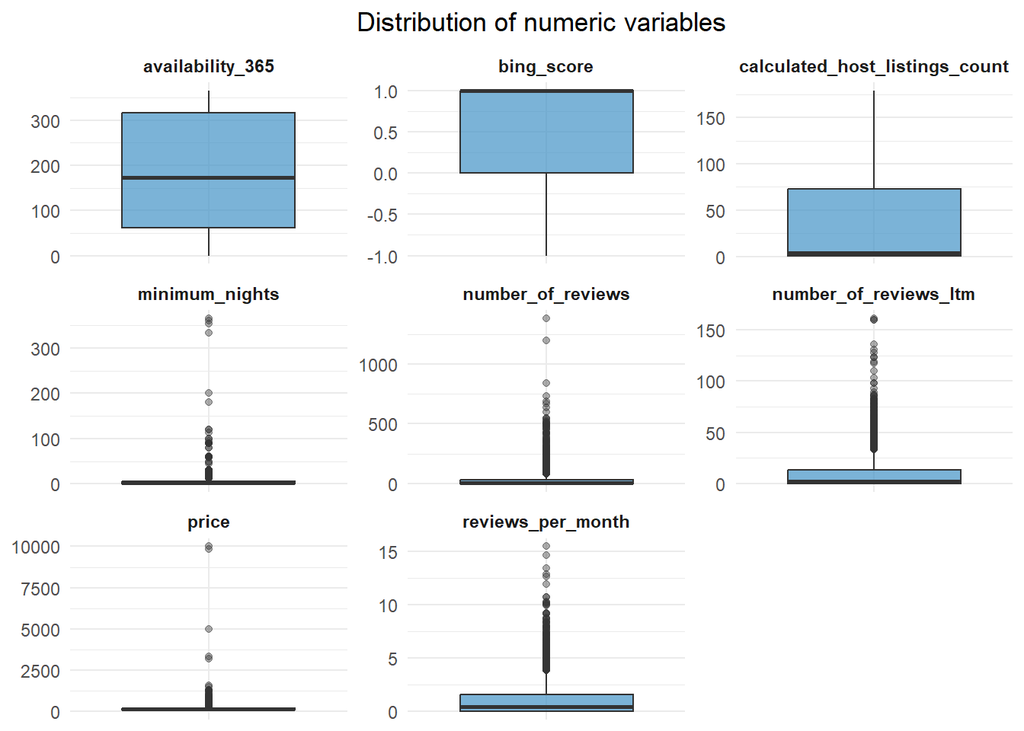

```r
boxplot_data <- d.merged %>%
  distinct(id, .keep_all = TRUE) %>%
  select(
    where(is.numeric),
    -any_of(vars_exclude)
  ) %>%
  pivot_longer(
    everything(),
    names_to  = "variable",
    values_to = "value"
  )

ggplot(boxplot_data, aes(x = "", y = value)) +
  geom_boxplot(
    fill  = "#4292c6",
    alpha = 0.7,
    outlier.alpha = 0.4
  ) +
  facet_wrap(
    ~ variable,
    scales = "free_y"
  ) +
  labs(
    title = "Distribution of numeric variables",
    x = NULL,
    y = NULL
  ) +
  theme_minimal() +
  theme(
    strip.text = element_text(face = "bold"),
    axis.text.x = element_blank(),
    axis.ticks.x = element_blank(),
    plot.title = element_text(hjust = 0.5)
  )
```

The summary statistics reveal substantial heterogeneity across listings. Prices are right-skewed, with a mean (168.63) above the median (136), indicating the presence of high-priced listings. A similar right-skewed pattern appears for review counts and host listing counts, suggesting that while most listings and hosts operate at moderate levels, a small number are highly active. In particular, the high values of calculated_host_listings_count indicate that some hosts manage many properties, which likely reflects professional operators or companies rather than individual hosts.

Minimum nights is generally low (median = 2), but extreme values exist, reflecting some listings with strict booking requirements. Availability varies considerably across listings, indicating differences in how intensively properties are offered.

The sentiment score is strongly concentrated at positive values (median = 1), confirming that most reviews are favorable.

Although several variables exhibit extreme values, these appear economically plausible and are therefore retained in the analysis.

## 2.4 Correlation Analysis and multicollinearity

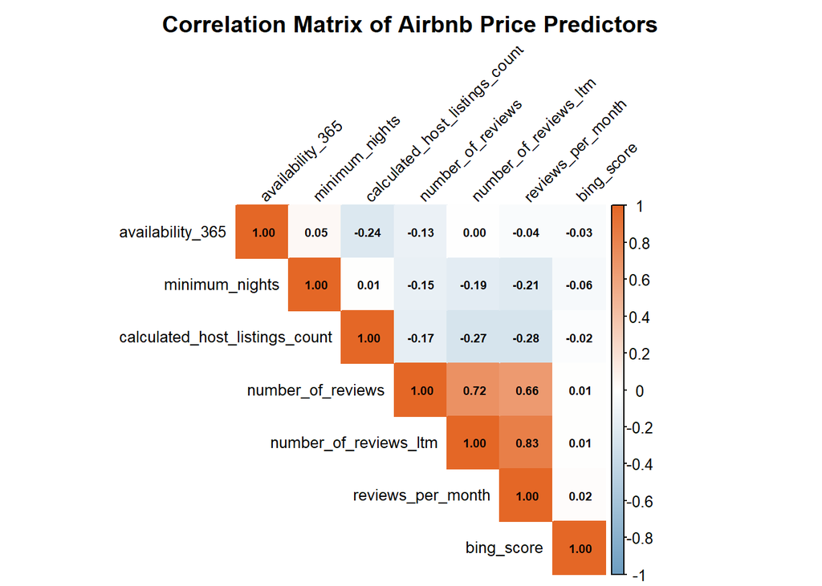

```r
# --- numeric data (exclude coords + intermediate sentiment counts) ---
airbnb_numeric <- d.merged %>%
  select(
    price,
    availability_365,
    minimum_nights,
    calculated_host_listings_count,
    number_of_reviews,
    number_of_reviews_ltm,
    reviews_per_month,
    bing_score
  )

# --- correlations ---
cor_predictors <- cor(airbnb_numeric %>% select(-price), use = "complete.obs")

# --- same colors as your example ---
my_cols <- colorRampPalette(c("#6D9EC1", "white", "#E46726"))(200)

corrplot(
  cor_predictors,
  method       = "color",
  type         = "upper",
  tl.col       = "black",
  tl.srt       = 45,
  tl.cex       = 0.8,
  addCoef.col  = "black",
  number.cex   = 0.6,
  col          = my_cols,
  cl.lim       = c(-1, 1),              # force same scale & colors
  title        = "Correlation Matrix of Airbnb Price Predictors",
  mar          = c(0, 0, 2, 0)
)
```

To assess the relationships among the main numeric predictors, a correlation matrix was computed. Overall, most variables exhibit weak pairwise correlations, suggesting limited concerns regarding multicollinearity. In particular, availability, minimum nights, host listing count, and sentiment score show only small correlations with other predictors.

However, strong positive correlations are observed among the review-related variables. The total number of reviews, the number of reviews in the last twelve months, and reviews per month are highly correlated, indicating that these variables capture a similar underlying dimension of listing popularity. Including all of them simultaneously in a regression model could therefore introduce multicollinearity and inflate standard errors. For this reason, only a the variabel total number of reviews will be included in the linear model done later.

Overall, aside from the review-related measures, the correlation matrix suggests that the explanatory variables are largely independent, supporting the robustness of the regression analysis.

# 3 Exploratory Data Anaylsis and Visualization

To answer the research questions, the data must be analysed. In this chapter, different visualizations are examined and their implications discussed. The visualizations are based on the merged dataset from the previous chapter. For most visualizations interim datasets are created, serving as short-term data variables. This allows to keep the *base* dataset clean while loading only the necessary data for visualization and performing data transformations on it if needed.

## 3.1 Number of listings per room type

First we visualize the number of listings according to the room types. For that it a horizontal barchart displaying the ranking was created.

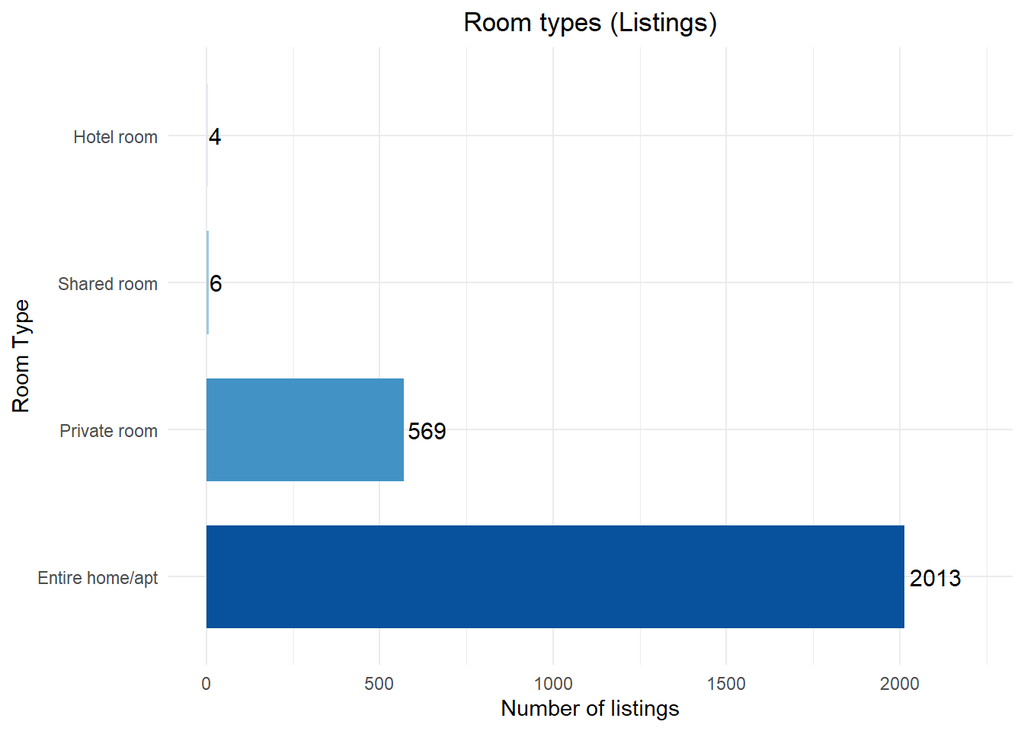

```r
# Listing-level counts per room type
room_counts <- d.merged %>%
  distinct(id, room_type) %>%
  count(room_type, name = "value") %>%
  mutate(
    room_type = factor(
      room_type,
      levels = c(
        "Entire home/apt",
        "Private room",
        "Shared room",
        "Hotel room"
      )
    )
  )

# Horizontal bar chart
ggplot(
  room_counts,
  aes(
    x    = value,
    y    = room_type,
    fill = room_type
  )
) +
  geom_col(width = 0.7) +
  geom_text(
    aes(label = value),
    hjust = -0.1,
    size = 4
  ) +
  scale_fill_manual(
    values = c(
      "Entire home/apt" = "#08519c",
      "Private room"    = "#4292c6",
      "Shared room"     = "#9ecae1",
      "Hotel room"      = "#deebf7"
    ),
    guide = "none"
  ) +
  labs(
    title = "Room types (Listings)",
    x = "Number of listings",
    y = "Room Type"
  ) +
  expand_limits(x = max(room_counts$value) * 1.1) +
  theme_minimal() +
  theme(
    plot.title = element_text(hjust = 0.5)
  )
```

From this visual it is evident that the most listings are rented as entire homes/apartments, followed by private rooms. Hotel and shared rooms make a negligible part of the distribution. Private rooms where guests live in the home of the host are making about one quarter of all listings and the majority of listings take up about three quarters. This means that most listings use entire apartment which take up a lot of living space in comparison to private rooms which are used by the people living in them regardless if the private room is rented or not.

## 3.2 Neighbourhood group characteristics

In this section the different neighborhood group characteristics are analyzed. For that the groups are measured according to their total number of hosts and listings as well as their mean price and mean number of minimum nights of a stay.

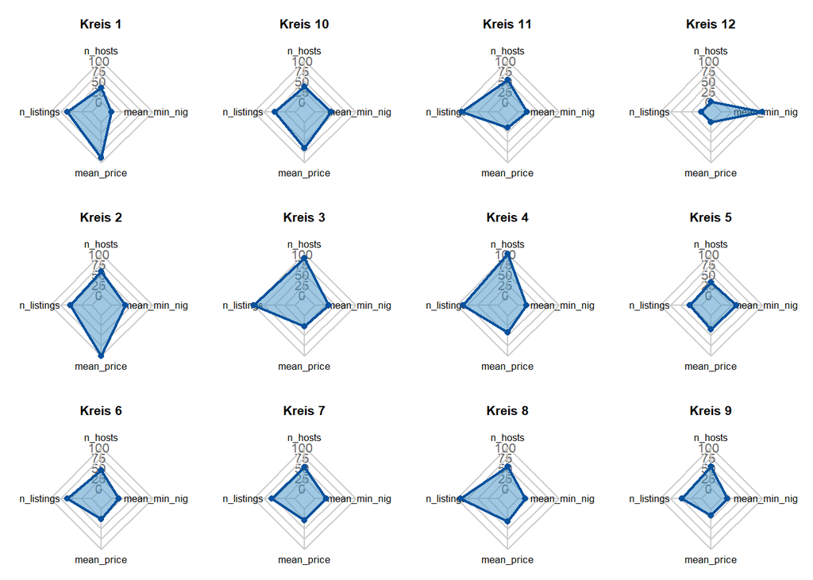

```r
listings <- d.merged %>%
  distinct(id, .keep_all = TRUE)

# Aggregate at neighbourhood_group level
radar_raw <- listings %>%
  group_by(neighbourhood_group) %>%
  summarise(
    n_hosts        = n_distinct(host_id),
    n_listings     = n(),  # number of listings in this group
    mean_price      = mean(price, na.rm = TRUE),
    mean_min_nights = mean(minimum_nights, na.rm = TRUE),
    .groups = "drop"
  )

radar_scaled <- radar_raw %>%
  mutate(
    n_hosts        = rescale(n_hosts,        to = c(0, 100)),
    n_listings     = rescale(n_listings,     to = c(0, 100)),
    mean_price      = rescale(mean_price,      to = c(0, 100)),
    mean_min_nights = rescale(mean_min_nights, to = c(0, 100))
  )

# Set up a 3 x 4 layout for 12 neighbourhood groups
par(mfrow = c(3, 4), mar = c(1, 1, 3, 1))

# Precompute global max and min for the axes (after scaling)
axis_max <- apply(radar_scaled[, -1], 2, max)
axis_min <- apply(radar_scaled[, -1], 2, min)

for (g in radar_scaled$neighbourhood_group) {
  # pick one neighbourhood
  row_g <- radar_scaled %>%
    filter(neighbourhood_group == g) %>%
    select(n_hosts, n_listings, mean_price, mean_min_nights)

  # build the data frame: max row, min row, group row
  df_radar <- rbind(axis_max, axis_min, row_g)
  rownames(df_radar) <- c("max", "min", as.character(g))

  radarchart(
    df_radar,
    axistype = 1,
    pcol     = "#08519c",
    pfcol    = scales::alpha("#4292c6", 0.5),
    plwd     = 2,
    cglcol   = "grey80",
    cglty    = 1,
    axislabcol = "grey40",
    caxislabels = c("0", "25", "50", "75", "100"),
    vlcex    = 0.8
  )
  title(main = g, cex.main = 1)
}
```

As an overall insights: * The numbers of listings and hosts tend to move together meaning groups with many listings also usually have many hosts. This may indicate active Airbnb markets instead of a few large-scale hosts. * Mean price varies more stronlgy than mean minimum nights. Generally, the minimum nights stay moderate across the city. * Each group has a different profile suggesting no uniform market.

While we will not go into details of all neighbourhood groups, we will highlight some of them.

Kreis 1, the Old Town, displays higher prices, a moderate number of listings and hosts and shorter minimum stays. This is propably because of its smaller size and likely driven by tourists and business travelers looking for a premium markert. Kreis 2 shows a similar profile.

Kreis 3 and 4 with the popular neighbourhood’s have profiles with the most hosts and listings indicating the most active market. Which might be also the most affected by possible changes to renting regulations.

### 3.2.1 Distribution of minimum nights

The histogram shows the distribution of minimum nights requirement for each listing across Zurich. It is based on the listings-level data and restricted to values between 1 and 35 nights.

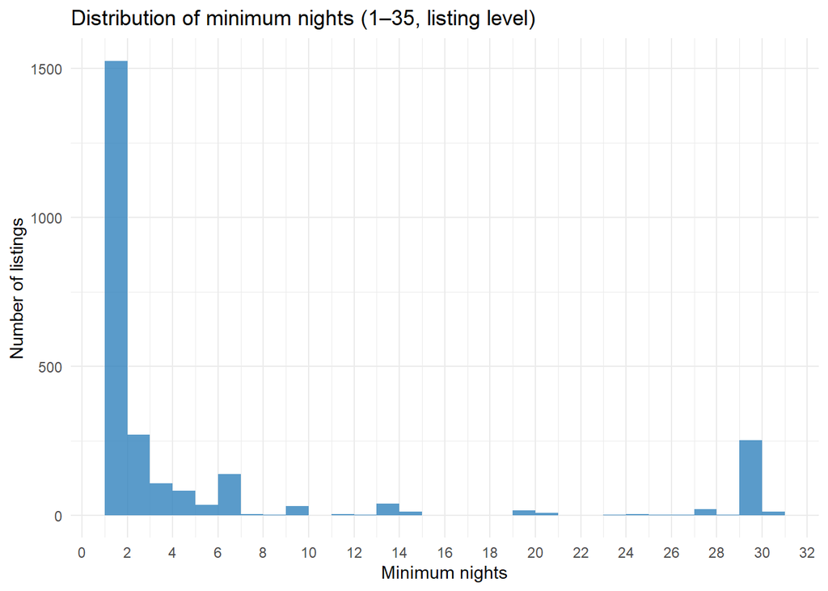

```r
interim <- d.merged %>%
  distinct(id, .keep_all = TRUE)

ggplot(
  interim %>% filter(minimum_nights <= 35),
  aes(x = minimum_nights)
) +
  geom_histogram(
    binwidth = 1,
    fill = "#3182bd",
    alpha = 0.8,
    boundary = 0
  ) +
  scale_x_continuous(breaks = seq(0, 35, 2)) +
  labs(
    title = "Distribution of minimum nights (1–35, listing level)",
    x = "Minimum nights",
    y = "Number of listings"
  ) +
  theme_minimal()
```

The distribution is highly right-skewed, the majority of listings only require a minimum stay of 1 or 2 nights. This insight suggests that short-term visists might be the favoured type of stay and may displace long-term housing. However, more information is needed to confirm this insight.

The distribution then decays quickly up to 7 minimum nights. After that there are some notable spikes in the long-tail, for example the minimum stay of 20 nights. But these make only a marginal part of the distribution. Yet, there is a significant spike at 30 minimum nights. These might suggest strategic offerings made by hosts to accomodate to special demands.

Overall, the distribution highlights a dominant short-term rental segment characterised by very low minimal stay requirements along side a small but visible group targeting longer stays.

```r
min_nights <- d.merged %>%
  distinct(id, minimum_nights) %>%
  count(minimum_nights) %>%
  arrange(minimum_nights) %>%
  mutate(
    share = n / sum(n),
    cum_share = cumsum(share)
  )

print(n = 53, min_nights)
```

```
## # A tibble: 42 × 4
##    minimum_nights     n    share cum_share
##             <dbl> <int>    <dbl>     <dbl>
##  1              1   826 0.319        0.319
##  2              2   700 0.270        0.589
##  3              3   269 0.104        0.693
##  4              4   107 0.0413       0.734
##  5              5    81 0.0312       0.765
##  6              6    34 0.0131       0.778
##  7              7   138 0.0532       0.831
##  8              8     3 0.00116      0.833
##  9              9     1 0.000386     0.833
## 10             10    31 0.0120       0.845
## 11             12     3 0.00116      0.846
## 12             13     1 0.000386     0.846
```

[output cut: 30 more lines]

### 3.2.2 Minimum nights per neighbourhood map

The visual below deepens our knowledge of the previous insights regarding minimum nights per stay. It displays the mean minimum nights of all listings per neighbourhood as a bubble map. The bigger the bubble the higher the minimum nights mean value.

Most of the neighbourhoods have a mean between 1 and 19. The closer you get to the Old Town, the lower the mean of the required minimum stay gets. Neighbourhood *Saatlen*, with a mean of 43.5, is the only neighbourhood where the mean minimum stay is over 19.

With this visualization it is possible double down on some of the insights and hyptotheses from the previous section. Most of the listings cater for short-term rentals, possible for tourists or business clients.

```r
geojson <- st_read("Data/neighbourhoods.geojson")
```

```r
listings <- d.merged %>%
  distinct(id, .keep_all = TRUE)

# mean minimum_nights per neighbourhood
neigh_stats <- listings %>%
  group_by(neighbourhood) %>%
  summarise(
    mean_minimum_nights = mean(minimum_nights, na.rm = TRUE),
    n_listings         = n(),
    .groups = "drop"
  )

# Join to neighbourhood polygons and transform to WGS84 (lat/lon)
geo_min <- geojson %>%
  left_join(neigh_stats, by = "neighbourhood")

geo_min_4326 <- st_transform(geo_min, 4326)

# Point per neighbourhood (for bubbles)
neigh_pts <- st_point_on_surface(geo_min_4326)
coords    <- st_coordinates(neigh_pts)

pts_df <- cbind(
  st_drop_geometry(neigh_pts),
  lon = coords[, "X"],
  lat = coords[, "Y"]
)

# Colour + size
pal <- colorNumeric("cividis", domain = pts_df$mean_minimum_nights)
radius_scaled <- rescale(pts_df$mean_minimum_nights, to = c(4, 16))

# Interactive leaflet map with neighbourhood borders
leaflet(geo_min_4326) %>%
  addProviderTiles(providers$OpenStreetMap.Mapnik) %>%

  # neighbourhood outlines
  addPolygons(
    color         = "#444444",     # border colour
    weight        = 1.2,           # thickness of line
    opacity       = 0.9,
    fill          = FALSE,         # just outlines
    highlightOptions = highlightOptions(
      color = "red",
      weight = 2,
      bringToFront = TRUE
    ),
    label = ~neighbourhood         # hover label on polygons
  ) %>%

  # bubbles per neighbourhood
  addCircleMarkers(
    data        = pts_df,
    lng         = ~lon,
    lat         = ~lat,
    radius      = radius_scaled,
    color       = "#ffffff",
    weight      = 1,
    fillColor   = ~pal(mean_minimum_nights),
    fillOpacity = 0.85,
    popup = ~paste0(
      "<b>", neighbourhood, "</b><br>",
      "Mean minimum nights: ", round(mean_minimum_nights, 1), "<br>",
      "Listings: ", n_listings
    )
  ) %>%

  addLegend(
    pal      = pal,
    values   = ~mean_minimum_nights,
    position = "bottomright",
    title    = "Mean minimum nights"
  )
```

[interactive chart not shown]

### 3.2.3 Mean price and number of stays per neighbourhood maps

The visual below displays once the mean price and once the number of stays each per neighbourhood. The higher the value the lighter the coloring of the neighbourhood.

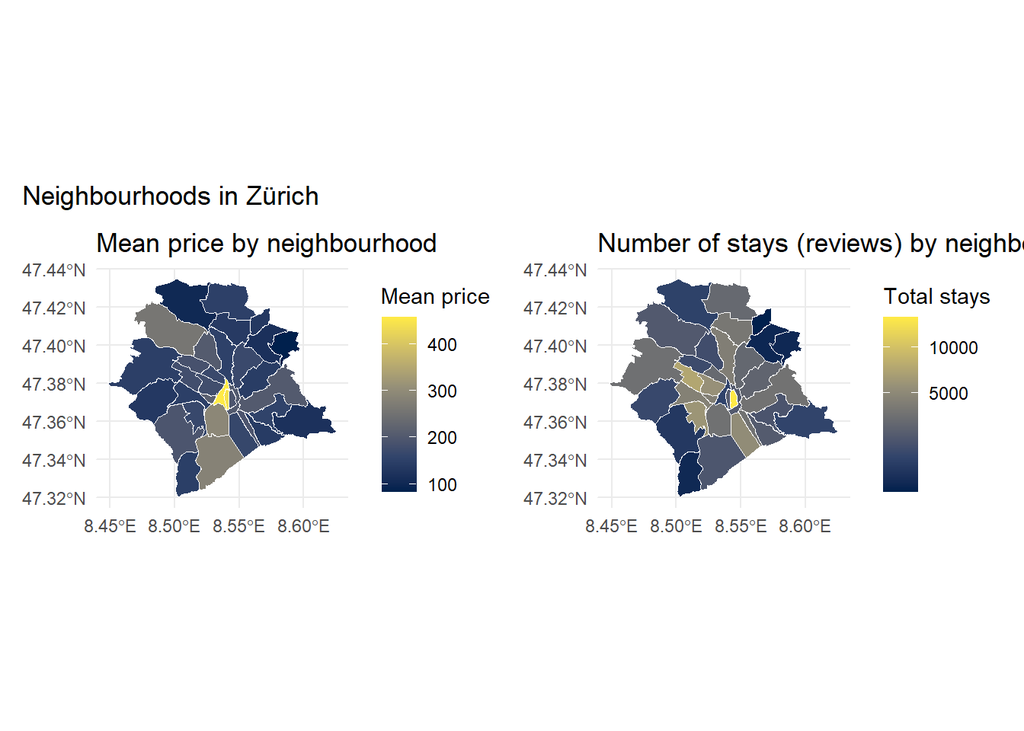

```r
listings <- d.merged %>%
  distinct(id, .keep_all = TRUE)

# Neighbourhood-level stats based on listings
map_stats <- listings %>%
  group_by(neighbourhood) %>%
  summarise(
    mean_price   = mean(price, na.rm = TRUE),
    total_stays  = sum(number_of_reviews, na.rm = TRUE),
    n_listings   = n(),
    .groups = "drop"
  )

# Join stats to neighbourhood geometries
geo_stats <- geojson %>%
  left_join(map_stats, by = "neighbourhood")

# Mean price map (neighbourhood)
p_price <- ggplot(geo_stats) +
  geom_sf(aes(fill = mean_price), color = "white", linewidth = 0.2) +
  scale_fill_viridis_c(option = "cividis") +
  labs(
    title = "Mean price by neighbourhood",
    fill  = "Mean price"
  ) +
  theme_minimal()

# Number of stays map (neighbourhood)
p_stays <- ggplot(geo_stats) +
  geom_sf(aes(fill = total_stays), color = "white", linewidth = 0.2) +
  scale_fill_viridis_c(option = "cividis", trans = "sqrt") +
  labs(
    title = "Number of stays (reviews) by neighbourhood",
    fill  = "Total stays"
  ) +
  theme_minimal()

# Combine plots
p_price + p_stays + plot_annotation(title = "Neighbourhoods in Zürich")
```

The prices tend to be higher the closer the neighbourhood group is to the city center. This does not come as a surprise as most people want to minimize their time spent traveling to the city center for their stays. Therefore, listings close to the city center are desired and prices reflect this demand.

However, the number of stays per neighbourhoods reveals, that while the city center is the most popular according to number of stays, other neighbourhoods in close proximity also record a lot of bookings and are quite popular among guests.

## 3.3 Reviews analysis maps

Below the two maps visualize negative reviews. The left map displays the absolute number of negative reviews, while the right map shows the proportion of negative reviews.

[figure not shown]

```r
neg_stats <- d.merged %>%
  filter(bing_score == -1) %>%
  group_by(neighbourhood) %>%
  summarise(
    n_negative_reviews = n(),
    .groups = "drop"
  )

all_stats <- d.merged %>%
  group_by(neighbourhood) %>%
  summarise(
    number_of_reviews = n(),
    .groups = "drop"
  )

neg_stats <- neg_stats %>%
  left_join(all_stats, by = "neighbourhood") %>%
  mutate(
    share_negative = n_negative_reviews / number_of_reviews
  )

geo_neg <- geojson %>%
  left_join(neg_stats, by = "neighbourhood")

p_count <- ggplot(geo_neg) +
  geom_sf(aes(fill = n_negative_reviews), color = "white", linewidth = 0.2) +
  scale_fill_viridis_c(
    option = "cividis",
    na.value = "grey90",
    name = "Negative reviews"
  ) +
  labs(
    title = "Number of negative reviews per neighbourhood",
    subtitle = "Lighter areas have more negative reviews"
  ) +
  theme_minimal()

p_share <- ggplot(geo_neg) +
  geom_sf(aes(fill = share_negative), color = "white", linewidth = 0.2) +
  scale_fill_viridis_c(
    option = "cividis",
    na.value = "grey90",
    labels = scales::percent_format(accuracy = 1),
    name = "% negative"
  ) +
  labs(
    title = "Share of negative reviews per neighbourhood",
    subtitle = "Fraction of reviews with bing_score = -1"
  ) +
  theme_minimal()

p_count + p_share + plot_annotation(
  title = "Negative Airbnb reviews in Zürich by neighbourhood"
)
```

According to the left map, on first view one might believe that the city center receives by far the most negative reviews. But the city center is also the place with the most amount of stays and therefore the most reviews. Thus the proportion of negative reviews must be taken into account, which displays a more nuanced picture.

The city center is still one of the neighbourhoods with the highest percentage of negative reviews. Yet, there are much more neighbourhoods with a percentage above 2% and the neighbourhood *Friesenberg* even has a higher percentage than the city center.

Overall, the share of negative reviews is much more informative than the absolute number. Although there is spatial variation in the share of negative reviews, the absolute levels are low, with no neighbourhood exceeding approximately 2.5% negative feedback, suggesting generally high guest satisfaction citywide.

## 3.4 Listings per host

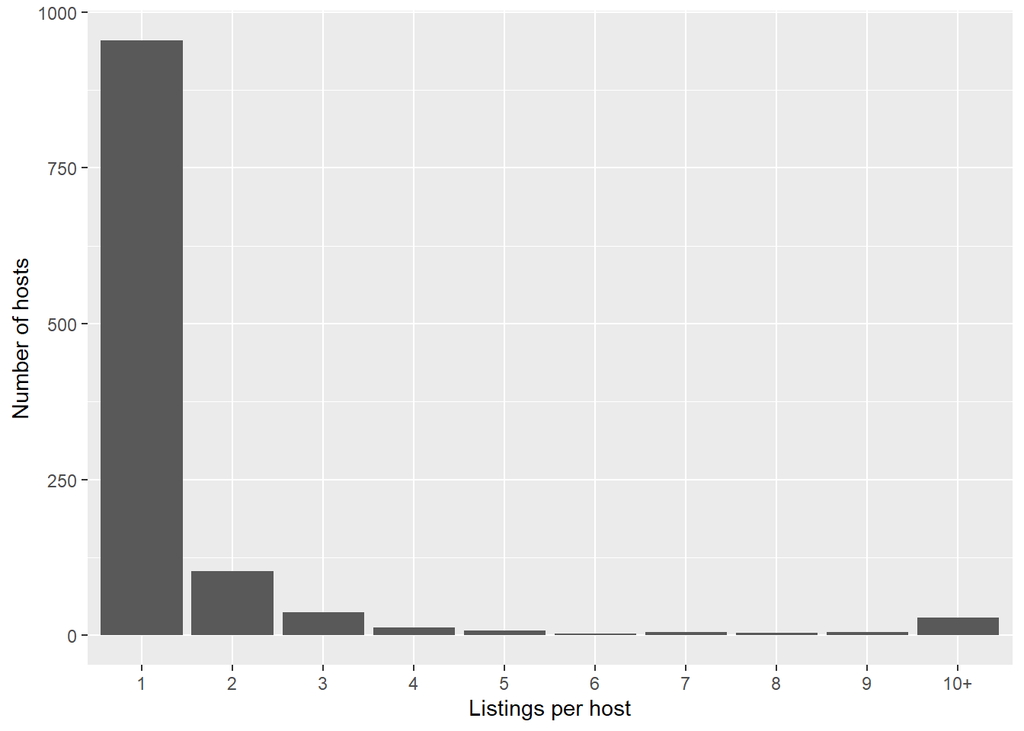

```r
# compute the number of listings per host
listings_per_host <- d.merged %>%
  distinct(host_id, id) %>%                    # keep one row per listing per host
  count(host_id, name = "listings_per_host")   # count listings per host

# group hosts with 10 or more listings
listings_per_host <- listings_per_host %>%
  mutate(listings_group =
           ifelse(
             listings_per_host >= 10,           # condition: 10+ listings
             "10+",                             # group them as "10+"
             as.character(listings_per_host)    # otherwise keep exact number
           ))

# convert grouped variable into a factor to order on the x-axis
listings_per_host <- listings_per_host %>%
  mutate(listings_group = factor(
    listings_group,
    levels = c(as.character(1:9), "10+")        # ensure "10+" appears at the end
  ))

# bar chart showing the number of hosts by listings per host group
ggplot(data = listings_per_host,
       mapping = aes(x = listings_group)) +
  geom_bar() +
  xlab("Listings per host") +
  ylab("Number of hosts")
```

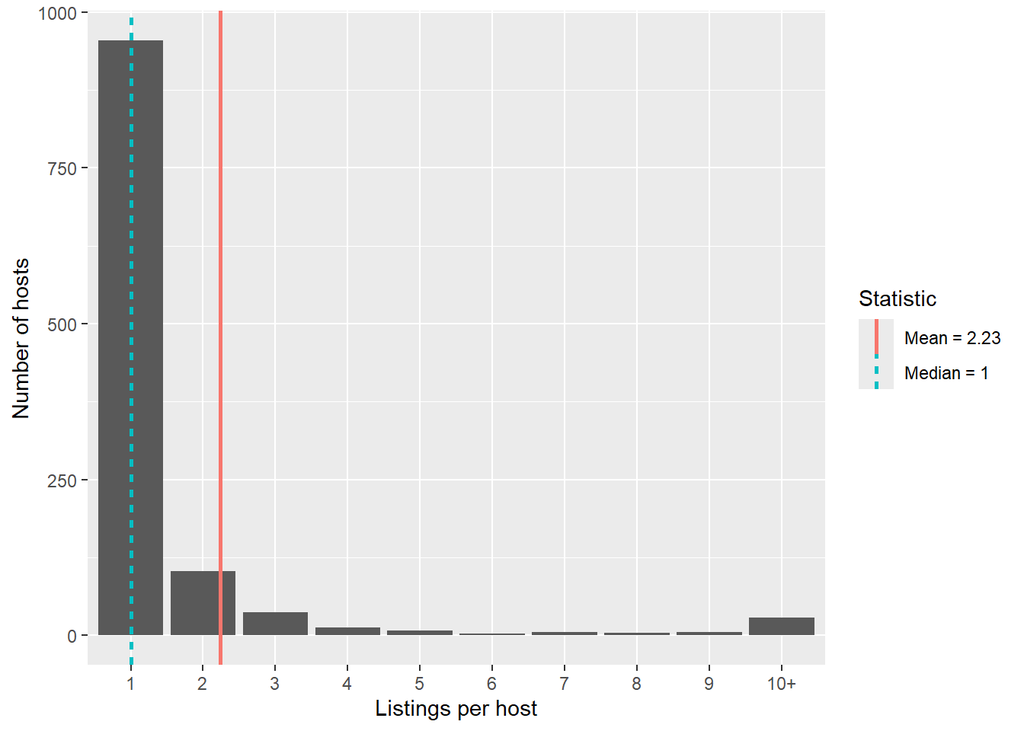

```r
# create mean and median lines and legend
stats_lines <- data.frame(
  statistic = c(
    paste0("Mean = ", round(mean(listings_per_host$listings_per_host), 2)),
    paste0("Median = ", median(listings_per_host$listings_per_host))
  ),
  value = c(
    mean(listings_per_host$listings_per_host),
    median(listings_per_host$listings_per_host)
  )
)

ggplot(listings_per_host, aes(x = listings_group)) +
  geom_bar() +

  geom_vline(data = stats_lines,
             aes(xintercept = value,
                 color = statistic,
                 linetype = statistic),
             linewidth = 1) +

  labs(color = "Statistic",
       linetype = "Statistic") +

  xlab("Listings per host") +
  ylab("Number of hosts")
```

The distribution of listings per host is highly right-skewed. The median host operates a single listing, while the mean of 2.23 listings per host reflects the presence of a smaller group of multi-listing hosts. This indicates that the Airbnb market is primarily composed of individual hosts, although a minority of more professional hosts contributes disproportionately to total supply.

## 3.5 Hotels per neighbourhood

```r
# load neighbourhood polygons (GeoJSON file)
neighbourhoods <- st_read("Data/neighbourhoods.geojson")
```

```r
# get hotels from OpenStreetMap
osm_hotels <- opq("Zurich, Switzerland", timeout = 400) %>%
  add_osm_feature(key = "tourism", value = "hotel") %>%
  osmdata_sf()

# keep hotel polygons and convert each polygon to ONE point
hotels <- st_point_on_surface(osm_hotels$osm_polygons)

# --- Airbnb: use d.merged, only 2025, one row per apartment id  <-- CAMBIADO
airbnb_2025 <- d.merged %>%                                    # <-- CAMBIADO
  filter(year(review_date) == 2025) %>%
  distinct(id, .keep_all = TRUE)                               # <-- CAMBIADO

# simple interactive map with neighbourhoods and hotels
leaflet() %>%
  addTiles() %>%
  addPolygons(
    data = neighbourhoods, # add base map
    weight = 2,            # thinner borders
    fill = 1
  ) %>%
  addCircleMarkers(
    data = hotels,
    radius = 2,
    fillOpacity = 1,
    color = "black"
  ) %>%

  # Airbnb listings (filtered 2025, unique ids)  <-- CAMBIADO
  addCircleMarkers(
    data = airbnb_2025,                                        # <-- CAMBIADO
    lng = ~longitude,
    lat = ~latitude,
    radius = 2,
    stroke = FALSE,
    fillOpacity = 1,
    color = "red"
  )
```

[interactive chart not shown]

The map illustrates the geographic distribution of Airbnb listings (red points) and hotels (black points) across the city of Zurich. A clear spatial pattern emerges: Airbnb listings are highly concentrated in central districts, particularly in and around the city center. This clustering reflects the strong demand for short-term accommodation in areas with high accessibility, tourism activity, and proximity to major attractions.

Hotels are also primarily located in central and well-connected areas. However, compared to Airbnb listings, their spatial distribution appears more concentrated and less dense. In several outer neighbourhoods, Airbnb listings are present despite the absence of nearby hotels.

This spatial mismatch suggests that Airbnb may complement the traditional hotel sector in certain areas. In neighbourhoods where hotel infrastructure is limited or absent, Airbnb potentially increases accommodation capacity and improves geographic coverage for visitors. Conversely, in central districts where both Airbnb listings and hotels are densely concentrated, Airbnb may act more as a competitor rather than a complement to hotels.

The dynamic nature of the map allows the City of Zurich to evaluate neighbourhood-level patterns in detail. Policymakers can identify areas where Airbnb listings expand accommodation supply in underserved zones, as well as areas where short-term rentals may contribute to high tourism pressure or housing market strain. This spatial differentiation provides valuable evidence for designing targeted regulatory or urban planning strategies.

```r
sf::sf_use_s2(FALSE)

# 1) Renombrar el barrio del GeoJSON para evitar neighbourhood.x / neighbourhood.y
neighbourhoods2 <- neighbourhoods %>%
  rename(neigh_poly = neighbourhood)

# 2) Airbnb 2025 -> puntos sf (1 fila por listing id)
airbnb_2025_sf <- d.merged %>%
  filter(format(review_date, "%Y") == "2025") %>%
  distinct(id, .keep_all = TRUE) %>%
  st_as_sf(coords = c("longitude", "latitude"), crs = 4326)

# 3) Contar Airbnbs 2025 por barrio
airbnbs_by_neigh <- neighbourhoods2 %>%
  st_join(airbnb_2025_sf, join = st_contains) %>%
  st_drop_geometry() %>%
  count(neigh_poly, name = "n_airbnbs_2025")

# 4) Contar Hoteles por barrio (hotels ya es sf de puntos)
hotels_by_neigh <- neighbourhoods2 %>%
  st_join(hotels, join = st_contains) %>%
  st_drop_geometry() %>%
  count(neigh_poly, name = "n_hotels")

# 5) Tabla final (incluye barrios con 0)
comparison <- neighbourhoods2 %>%
  st_drop_geometry() %>%
  distinct(neigh_poly) %>%
  left_join(airbnbs_by_neigh, by = "neigh_poly") %>%
  left_join(hotels_by_neigh, by = "neigh_poly") %>%
  mutate(
    n_airbnbs_2025 = coalesce(n_airbnbs_2025, 0),
    n_hotels = coalesce(n_hotels, 0),
    airbnbs_per_hotel = ifelse(n_hotels == 0, NA, n_airbnbs_2025 / n_hotels)
  ) %>%
  arrange(desc(airbnbs_per_hotel))

comparison
```

```
##              neigh_poly n_airbnbs_2025 n_hotels airbnbs_per_hotel
## 1           Unterstrass            107        1         107.00000
## 2               Rathaus             98        1          98.00000
## 3              Sihlfeld             94        1          94.00000
## 4               Seebach             89        1          89.00000
## 5           Langstrasse             87        1          87.00000
## 6          Alt-Wiedikon             70        1          70.00000
## 7             Mühlebach             69        1          69.00000
## 8                  Hard             63        1          63.00000
## 9              Oerlikon             56        1          56.00000
## 10        Gewerbeschule             48        1          48.00000
## 11              Weinegg             47        1          47.00000
## 12           Oberstrass             45        1          45.00000
## 13            Hottingen             44        1          44.00000
## 14           Altstetten             44        1          44.00000
```

[output cut: 20 more lines]

## 3.6 Evolution of number of Airbnb listings

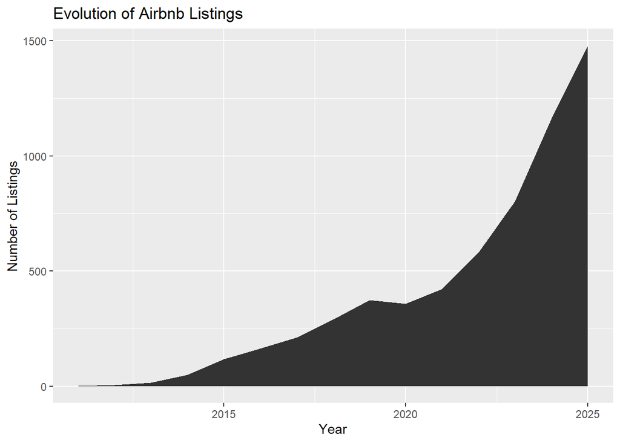

```r
listings_per_year <- d.merged %>%
  filter(!is.na(review_date)) %>%
  mutate(year = year(review_date)) %>%
  group_by(year) %>%
  summarise(n_listings = n_distinct(id))

ggplot(listings_per_year, aes(x = year, y = n_listings)) +
  geom_area() +
  labs(
    title = "Evolution of Airbnb Listings",
    x = "Year",
    y = "Number of Listings"
  )
```

The figure shows a strong upward trend in the number of Airbnb listings in Zurich over time. After gradual growth in the early years, listings increased steadily until 2019. Around 2020, growth temporarily slowed, likely due to the COVID-19 pandemic. From 2021 onward, the number of listings rose sharply, reaching approximately 1,500 by 2025. Overall, the trend indicates that Airbnb has become an increasingly important part of Zurich’s accommodation market.

## 3.7 Evolution of reviews

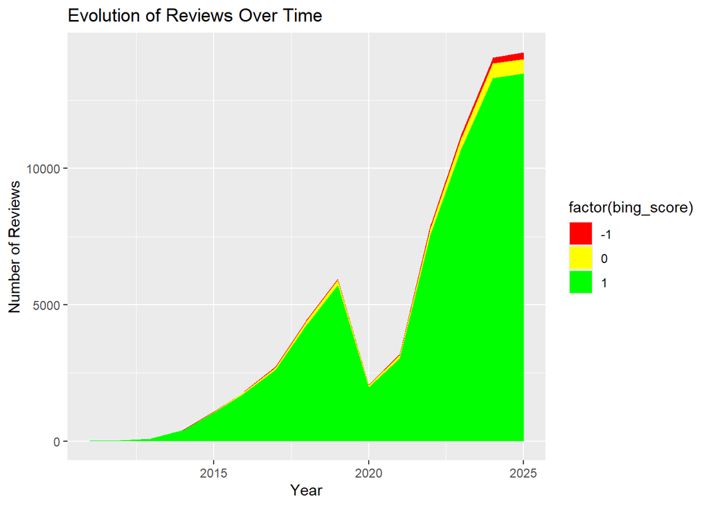

```r
reviews_year <- d.merged %>%
  filter(!is.na(review_date)) %>%
  mutate(year = year(review_date)) %>%
  group_by(year, bing_score) %>%
  summarise(number_of_reviews = n(), .groups = "drop")

ggplot(reviews_year,
       aes(x = year, y = number_of_reviews, fill = factor(bing_score))) +
  geom_area() +
  scale_fill_manual(
    values = c("-1" = "red",
               "0"  = "yellow",
               "1"  = "green")
  ) +
  labs(
    title = "Evolution of Reviews Over Time",
    x = "Year",
    y = "Number of Reviews"
  )
```

The figure shows a strong increase in the total number of Airbnb reviews over time, closely mirroring the growth in listings. Reviews rise steadily until 2019, decline sharply around 2020—likely due to the COVID-19 pandemic—and then increase rapidly again from 2021 onward.

The vast majority of reviews are positive (green), while neutral and negative reviews represent only a small share throughout the period. This indicates consistently high customer satisfaction despite the rapid expansion of the platform.

Overall, the trend suggests both growing market activity and persistently positive guest experiences over time.

# 4 Model - Prediction of price

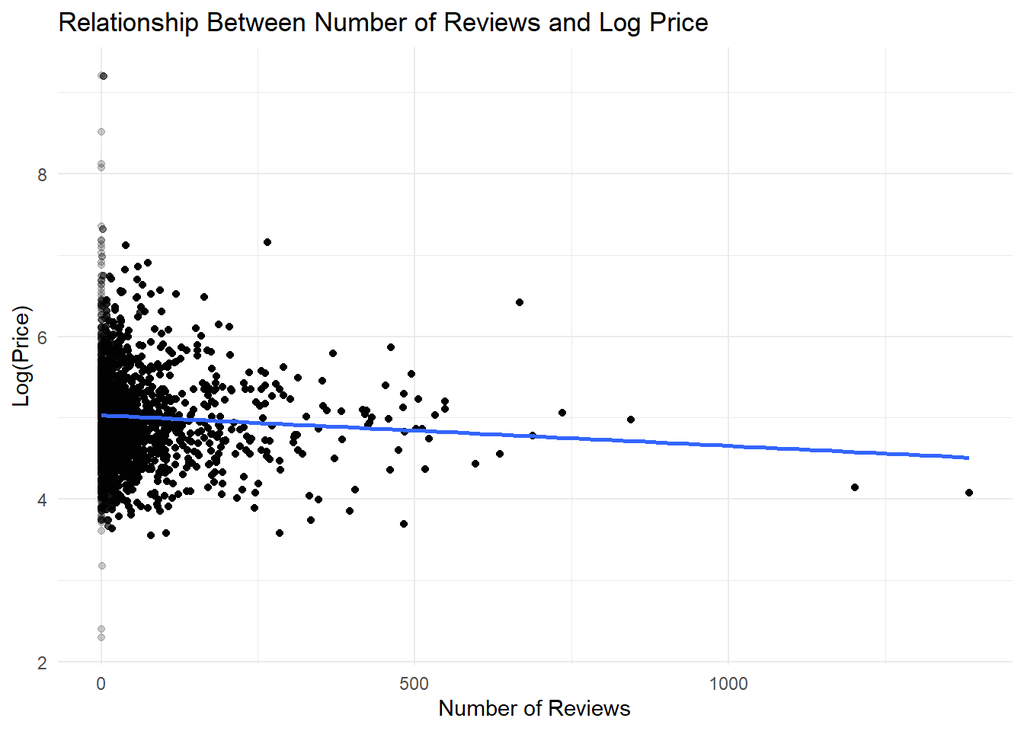

```r
ggplot(d.merged %>% filter(price > 0),
       aes(x = number_of_reviews, y = log(price))) +
  geom_point(alpha = 0.2) +
  geom_smooth(method = "lm", se = FALSE) +
  theme_minimal() +
  labs(
    title = "Relationship Between Number of Reviews and Log Price",
    x = "Number of Reviews",
    y = "Log(Price)"
  )
```

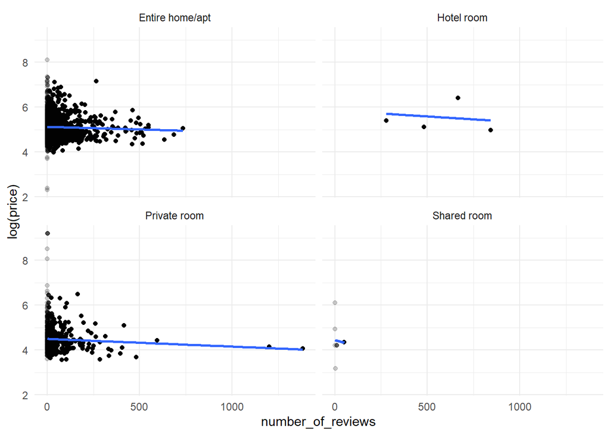

```r
ggplot(d.merged, aes(x = number_of_reviews, y = log(price))) +
  geom_point(alpha = 0.2) +
  geom_smooth(method = "lm", se = FALSE) +
  facet_wrap(~ room_type) +
  theme_minimal()
```

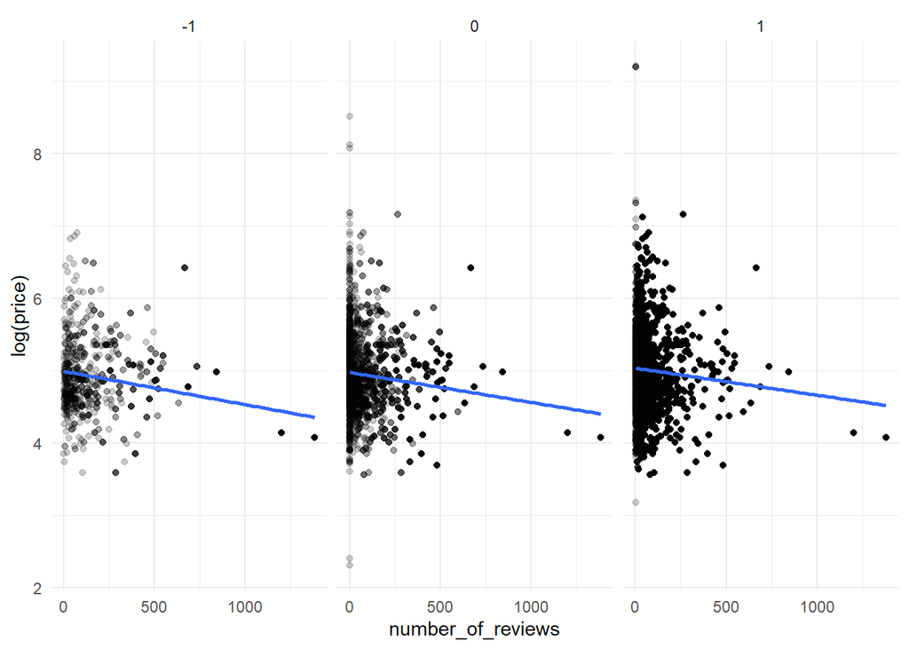

```r
ggplot(d.merged, aes(x = number_of_reviews, y = log(price))) +
  geom_point(alpha = 0.2) +
  geom_smooth(method = "lm", se = FALSE) +
  facet_wrap(~ factor(bing_score)) +
  theme_minimal()
```

```r
# Check if model already exists
if (file.exists("lm_model.rds")) {
  lm_model <- readRDS("lm_model.rds")
} else {

# log
  d.model <- d.listings_with_sentiment %>%
    mutate(
      log_price = log(price),
      room_type = relevel(room_type, ref = "Entire home/apt"),
      neighbourhood = relevel(neighbourhood, ref = "City")
    )

# Fit linear model
lm_model <- lm(log_price ~ room_type +
                           neighbourhood +
                           mean_bing_score +
                           number_of_reviews +
                           calculated_host_listings_count +
                           minimum_nights +
                           availability_365,
             data = d.model)
  # Save model
  saveRDS(lm_model, "lm_model.rds")
}

# Key coefficients
summary(lm_model)
```

```
##
## Call:
## lm(formula = log_price ~ room_type + neighbourhood + mean_bing_score +
##     number_of_reviews + calculated_host_listings_count + minimum_nights +
##     availability_365, data = d.model)
##
## Residuals:
##     Min      1Q  Median      3Q     Max
## -1.4443 -0.3193 -0.0714  0.2475  4.7685
##
## Coefficients:
##                                     Estimate Std. Error t value Pr(>|t|)
## (Intercept)                        5.766e+00  1.541e-01  37.418  < 2e-16 ***
## room_typeHotel room                4.032e-01  2.536e-01   1.590  0.11203
## room_typePrivate room             -5.195e-01  2.994e-02 -17.354  < 2e-16 ***
## room_typeShared room              -1.353e+00  2.810e-01  -4.814 1.60e-06 ***
## neighbourhoodAffoltern            -1.211e+00  1.640e-01  -7.387 2.27e-13 ***
## neighbourhoodAlbisrieden          -1.275e+00  1.614e-01  -7.899 4.80e-15 ***
## neighbourhoodAlt-Wiedikon         -1.099e+00  1.492e-01  -7.361 2.75e-13 ***
## neighbourhoodAltstetten           -1.070e+00  1.502e-01  -7.125 1.49e-12 ***
## neighbourhoodEnge                 -7.051e-01  1.504e-01  -4.688 2.96e-06 ***
## neighbourhoodEscher Wyss          -7.764e-01  1.792e-01  -4.333 1.55e-05 ***
## neighbourhoodFluntern             -9.045e-01  1.621e-01  -5.581 2.75e-08 ***
## neighbourhoodFriesenberg          -9.581e-01  1.714e-01  -5.590 2.61e-08 ***
## neighbourhoodGewerbeschule        -9.506e-01  1.531e-01  -6.207 6.66e-10 ***
## neighbourhoodHard                 -9.088e-01  1.509e-01  -6.024 2.05e-09 ***
## neighbourhoodHirslanden           -9.081e-01  1.619e-01  -5.608 2.36e-08 ***
## neighbourhoodHirzenbach           -1.432e+00  2.424e-01  -5.906 4.17e-09 ***
## neighbourhoodHochschulen          -8.138e-01  1.623e-01  -5.016 5.80e-07 ***
## neighbourhoodHöngg                -9.703e-01  1.599e-01  -6.070 1.55e-09 ***
## neighbourhoodHottingen            -8.571e-01  1.541e-01  -5.563 3.04e-08 ***
## neighbourhoodLangstrasse          -7.780e-01  1.478e-01  -5.265 1.57e-07 ***
## neighbourhoodLeimbach             -1.060e+00  2.303e-01  -4.603 4.45e-06 ***
## neighbourhoodLindenhof            -4.140e-01  1.625e-01  -2.547  0.01095 *
## neighbourhoodMühlebach            -8.726e-01  1.499e-01  -5.822 6.85e-09 ***
## neighbourhoodOberstrass           -9.584e-01  1.558e-01  -6.150 9.47e-10 ***
## neighbourhoodOerlikon             -1.072e+00  1.500e-01  -7.148 1.26e-12 ***
## neighbourhoodRathaus              -8.320e-01  1.475e-01  -5.642 1.95e-08 ***
## neighbourhoodSaatlen              -1.400e+00  3.130e-01  -4.471 8.25e-06 ***
## neighbourhoodSchwamendingen-Mitte -1.317e+00  2.306e-01  -5.712 1.30e-08 ***
## neighbourhoodSeebach              -1.067e+00  1.485e-01  -7.187 9.57e-13 ***
## neighbourhoodSeefeld              -8.716e-01  1.479e-01  -5.893 4.51e-09 ***
## neighbourhoodSihlfeld             -1.045e+00  1.467e-01  -7.121 1.53e-12 ***
## neighbourhoodUnterstrass          -1.011e+00  1.472e-01  -6.872 8.65e-12 ***
## neighbourhoodWeinegg              -1.116e+00  1.536e-01  -7.266 5.44e-13 ***
## neighbourhoodWerd                 -7.360e-01  1.566e-01  -4.700 2.79e-06 ***
## neighbourhoodWipkingen            -9.885e-01  1.548e-01  -6.386 2.15e-10 ***
## neighbourhoodWitikon              -1.189e+00  1.664e-01  -7.144 1.30e-12 ***
## neighbourhoodWollishofen          -7.765e-01  1.584e-01  -4.902 1.03e-06 ***
## mean_bing_score                    1.601e-01  5.839e-02   2.743  0.00615 **
## number_of_reviews                 -3.632e-04  1.248e-04  -2.909  0.00367 **
## calculated_host_listings_count    -6.660e-04  2.673e-04  -2.492  0.01280 *
## minimum_nights                    -5.221e-05  9.616e-04  -0.054  0.95671
## availability_365                   6.725e-04  9.362e-05   7.182 9.91e-13 ***
## ---
## Signif. codes:  0 '***' 0.001 '**' 0.01 '*' 0.05 '.' 0.1 ' ' 1
##
## Residual standard error: 0.4835 on 1831 degrees of freedom
##   (719 observations deleted due to missingness)
## Multiple R-squared:  0.281,  Adjusted R-squared:  0.2649
## F-statistic: 17.45 on 41 and 1831 DF,  p-value: < 2.2e-16
```

```r
# exp to be easier to interpret
round((exp(coef(lm_model)) - 1) * 100, 1)
```

```
##                       (Intercept)               room_typeHotel room
##                           31813.2                              49.7
##             room_typePrivate room              room_typeShared room
##                             -40.5                             -74.2
##            neighbourhoodAffoltern          neighbourhoodAlbisrieden
##                             -70.2                             -72.0
##         neighbourhoodAlt-Wiedikon           neighbourhoodAltstetten
##                             -66.7                             -65.7
##                 neighbourhoodEnge          neighbourhoodEscher Wyss
##                             -50.6                             -54.0
##             neighbourhoodFluntern          neighbourhoodFriesenberg
##                             -59.5                             -61.6
##        neighbourhoodGewerbeschule                 neighbourhoodHard
##                             -61.3                             -59.7
##           neighbourhoodHirslanden           neighbourhoodHirzenbach
##                             -59.7                             -76.1
##          neighbourhoodHochschulen                neighbourhoodHöngg
##                             -55.7                             -62.1
##            neighbourhoodHottingen          neighbourhoodLangstrasse
##                             -57.6                             -54.1
##             neighbourhoodLeimbach            neighbourhoodLindenhof
##                             -65.4                             -33.9
##            neighbourhoodMühlebach           neighbourhoodOberstrass
##                             -58.2                             -61.7
##             neighbourhoodOerlikon              neighbourhoodRathaus
##                             -65.8                             -56.5
##              neighbourhoodSaatlen neighbourhoodSchwamendingen-Mitte
##                             -75.3                             -73.2
##              neighbourhoodSeebach              neighbourhoodSeefeld
##                             -65.6                             -58.2
##             neighbourhoodSihlfeld          neighbourhoodUnterstrass
##                             -64.8                             -63.6
##              neighbourhoodWeinegg                 neighbourhoodWerd
##                             -67.2                             -52.1
##            neighbourhoodWipkingen              neighbourhoodWitikon
##                             -62.8                             -69.5
##          neighbourhoodWollishofen                   mean_bing_score
##                             -54.0                              17.4
##                 number_of_reviews    calculated_host_listings_count
##                               0.0                              -0.1
##                    minimum_nights                  availability_365
##                               0.0                               0.1
```

```r
effects <- broom::tidy(lm_model) %>%
  filter(term != "(Intercept)") %>%
  mutate(
    pct_effect = 100 * (exp(estimate) - 1),
    pct_effect = round(pct_effect, 1)
  ) %>%
  arrange(desc(abs(pct_effect)))

effects
```

```
## # A tibble: 41 × 6
##    term                         estimate std.error statistic  p.value pct_effect
##    <chr>                           <dbl>     <dbl>     <dbl>    <dbl>      <dbl>
##  1 neighbourhoodHirzenbach         -1.43     0.242     -5.91 4.17e- 9      -76.1
##  2 neighbourhoodSaatlen            -1.40     0.313     -4.47 8.25e- 6      -75.3
##  3 room_typeShared room            -1.35     0.281     -4.81 1.60e- 6      -74.2
##  4 neighbourhoodSchwamendingen…    -1.32     0.231     -5.71 1.30e- 8      -73.2
##  5 neighbourhoodAlbisrieden        -1.27     0.161     -7.90 4.80e-15      -72
##  6 neighbourhoodAffoltern          -1.21     0.164     -7.39 2.27e-13      -70.2
##  7 neighbourhoodWitikon            -1.19     0.166     -7.14 1.30e-12      -69.5
##  8 neighbourhoodWeinegg            -1.12     0.154     -7.27 5.44e-13      -67.2
##  9 neighbourhoodAlt-Wiedikon       -1.10     0.149     -7.36 2.75e-13      -66.7
## 10 neighbourhoodOerlikon           -1.07     0.150     -7.15 1.26e-12      -65.8
## # ℹ 31 more rows
```

```r
# Key effects (everything except neighbourhood)
effects_key <- effects %>%
  filter(!grepl("^neighbourhood", term))

effects_key
```

```
## # A tibble: 8 × 6
##   term                          estimate std.error statistic  p.value pct_effect
##   <chr>                            <dbl>     <dbl>     <dbl>    <dbl>      <dbl>
## 1 room_typeShared room          -1.35e+0 0.281       -4.81   1.60e- 6      -74.2
## 2 room_typeHotel room            4.03e-1 0.254        1.59   1.12e- 1       49.7
## 3 room_typePrivate room         -5.20e-1 0.0299     -17.4    1.42e-62      -40.5
## 4 mean_bing_score                1.60e-1 0.0584       2.74   6.15e- 3       17.4
## 5 calculated_host_listings_cou… -6.66e-4 0.000267    -2.49   1.28e- 2       -0.1
## 6 availability_365               6.72e-4 0.0000936    7.18   9.91e-13        0.1
## 7 number_of_reviews             -3.63e-4 0.000125    -2.91   3.67e- 3        0
## 8 minimum_nights                -5.22e-5 0.000962    -0.0543 9.57e- 1        0
```

```r
# Top 8 neighbourhood premiums and discounts (vs City)
top_neigh_plus  <- effects %>%
  filter(grepl("^neighbourhood", term)) %>%
  arrange(desc(pct_effect)) %>%
  slice(1:8)

top_neigh_minus <- effects %>%
  filter(grepl("^neighbourhood", term)) %>%
  arrange(pct_effect) %>%
  slice(1:8)

top_neigh_plus
```

```
## # A tibble: 8 × 6
##   term                     estimate std.error statistic      p.value pct_effect
##   <chr>                       <dbl>     <dbl>     <dbl>        <dbl>      <dbl>
## 1 neighbourhoodLindenhof     -0.414     0.163     -2.55 0.0109            -33.9
## 2 neighbourhoodEnge          -0.705     0.150     -4.69 0.00000296        -50.6
## 3 neighbourhoodWerd          -0.736     0.157     -4.70 0.00000279        -52.1
## 4 neighbourhoodEscher Wyss   -0.776     0.179     -4.33 0.0000155         -54
## 5 neighbourhoodWollishofen   -0.777     0.158     -4.90 0.00000103        -54
## 6 neighbourhoodLangstrasse   -0.778     0.148     -5.26 0.000000157       -54.1
## 7 neighbourhoodHochschulen   -0.814     0.162     -5.02 0.000000580       -55.7
## 8 neighbourhoodRathaus       -0.832     0.147     -5.64 0.0000000195      -56.5
```

```r
top_neigh_minus
```

```
## # A tibble: 8 × 6
##   term                          estimate std.error statistic  p.value pct_effect
##   <chr>                            <dbl>     <dbl>     <dbl>    <dbl>      <dbl>
## 1 neighbourhoodHirzenbach          -1.43     0.242     -5.91 4.17e- 9      -76.1
## 2 neighbourhoodSaatlen             -1.40     0.313     -4.47 8.25e- 6      -75.3
## 3 neighbourhoodSchwamendingen-…    -1.32     0.231     -5.71 1.30e- 8      -73.2
## 4 neighbourhoodAlbisrieden         -1.27     0.161     -7.90 4.80e-15      -72
## 5 neighbourhoodAffoltern           -1.21     0.164     -7.39 2.27e-13      -70.2
## 6 neighbourhoodWitikon             -1.19     0.166     -7.14 1.30e-12      -69.5
## 7 neighbourhoodWeinegg             -1.12     0.154     -7.27 5.44e-13      -67.2
## 8 neighbourhoodAlt-Wiedikon        -1.10     0.149     -7.36 2.75e-13      -66.7
```

Review sentiment also plays a meaningful role. There is strong evidence that the coefficient on the mean Bing score differs from zero (p < 0.01). A one-unit increase in sentiment is associated with approximately a 17% increase in price, suggesting that listings with more positive review tone are able to charge higher prices in Zurich.

For the number of reviews, there is strong evidence that the coefficient differs from zero (p < 0.05), but the magnitude is economically very small. For every additional review, the price decreases by approximately 0.035%, holding other factors constant. This suggests that while the association is statistically detectable, it is negligible in practical terms. A similar pattern is observed for the number of listings managed by a host. There is strong evidence that the coefficient differs from zero (p < 0.05), but each additional listing is associated with only about a 0.07% decrease in price. This may reflect slightly more competitive pricing strategies among professional hosts, though the economic impact is limited.

Overall, there is strong evidence that room type, neighbourhood, and review sentiment are important determinants of Airbnb prices in the City of Zurich. Other variables such as review counts, host portfolio size, and availability show statistically significant but economically minor effects, while minimum nights shows no measurable impact. Although the model is statistically robust, the moderate R² indicates that a considerable share of price variation is driven by additional factors not captured in the model.

## 4.1 Cross Validation

We additionally evaluate the predictive performance of the models using 5-fold cross-validation. This step is different from the previous regression analysis: while the original linear model was estimated on the full dataset to interpret relationships and coefficients, cross-validation assesses how well the models perform on unseen data. In each fold, the model is trained on part of the data and tested on observations that were not used for estimation.

We compare the original linear model (LM) with a polynomial version that includes nonlinear terms.

```r
set.seed(123)

# ------------------------------------------------------------
# 1) Prepare modeling data
# ------------------------------------------------------------
d.model <- d.listings_with_sentiment %>%
  filter(price > 0) %>%
  mutate(
    log_price = log(price),
    room_type = relevel(factor(room_type), ref = "Entire home/apt"),
    neighbourhood = relevel(factor(neighbourhood), ref = "City")
  )

# ------------------------------------------------------------
# 2) Cross-validation setup (5-fold CV)
# ------------------------------------------------------------
cv_control <- trainControl(
  method = "cv",
  number = 5
)

# ------------------------------------------------------------
# 3) Model 1: Original Linear Model (with saving)
# ------------------------------------------------------------
if (file.exists("cv_lm_price.rds")) {
  cv_lm <- readRDS("cv_lm_price.rds")
} else {
  cv_lm <- train(
    log_price ~ room_type + neighbourhood +
      mean_bing_score + number_of_reviews +
      calculated_host_listings_count +
      minimum_nights + availability_365,
    data = d.model,
    method = "lm",
    trControl = cv_control,
    metric = "RMSE",
    na.action = na.omit
  )

  saveRDS(cv_lm, "cv_lm_price.rds")
}

# ------------------------------------------------------------
# 4) Model 2: Polynomial Linear Model (with saving)
# ------------------------------------------------------------
if (file.exists("cv_poly_price.rds")) {
  cv_poly <- readRDS("cv_poly_price.rds")
} else {
  cv_poly <- train(
    log_price ~ room_type + neighbourhood +
      mean_bing_score + I(mean_bing_score^2) +
      number_of_reviews + I(number_of_reviews^2) +
      calculated_host_listings_count +
      minimum_nights + I(minimum_nights^2) +
      availability_365 + I(availability_365^2),
    data = d.model,
    method = "lm",
    trControl = cv_control,
    metric = "RMSE",
    na.action = na.omit
  )

  saveRDS(cv_poly, "cv_poly_price.rds")
}

# ------------------------------------------------------------
# 5) Compare numerical results
# ------------------------------------------------------------
cv_lm$results
```

```
##   intercept      RMSE  Rsquared       MAE     RMSESD RsquaredSD      MAESD
## 1      TRUE 0.4900367 0.2477944 0.3687859 0.03684964  0.0393654 0.01625191
```

```r
cv_poly$results
```

```
##   intercept     RMSE  Rsquared       MAE    RMSESD RsquaredSD      MAESD
## 1      TRUE 0.539904 0.2188437 0.3744362 0.1284994  0.1104843 0.01925369
```

```r
# ------------------------------------------------------------
# 6) Visual comparison across folds
# ------------------------------------------------------------
res <- resamples(list(LM = cv_lm, Polynomial = cv_poly))

summary(res)
```

```
##
## Call:
## summary.resamples(object = res)
##
## Models: LM, Polynomial
## Number of resamples: 5
##
## MAE
##                 Min.   1st Qu.    Median      Mean   3rd Qu.      Max. NA's
## LM         0.3532313 0.3582523 0.3617039 0.3687859 0.3781837 0.3925582    0
## Polynomial 0.3495447 0.3637602 0.3733932 0.3744362 0.3864968 0.3989863    0
##
## RMSE
##                 Min.   1st Qu.    Median      Mean   3rd Qu.      Max. NA's
## LM         0.4460669 0.4749464 0.4813096 0.4900367 0.5027545 0.5451059    0
## Polynomial 0.4556769 0.4676469 0.4946646 0.5399040 0.5155852 0.7659463    0
##
## Rsquared
##                 Min.   1st Qu.    Median      Mean   3rd Qu.      Max. NA's
## LM         0.1983871 0.2172685 0.2548734 0.2477944 0.2764222 0.2920206    0
## Polynomial 0.0366741 0.2055178 0.2414227 0.2188437 0.3039140 0.3066901    0
```

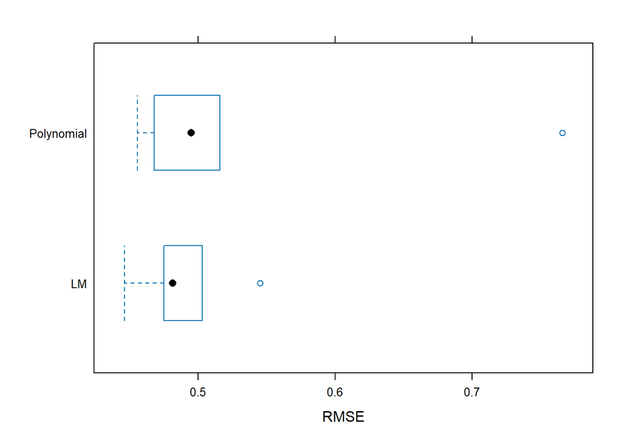

```r
bwplot(res, metric = "RMSE")     # lower = better
```

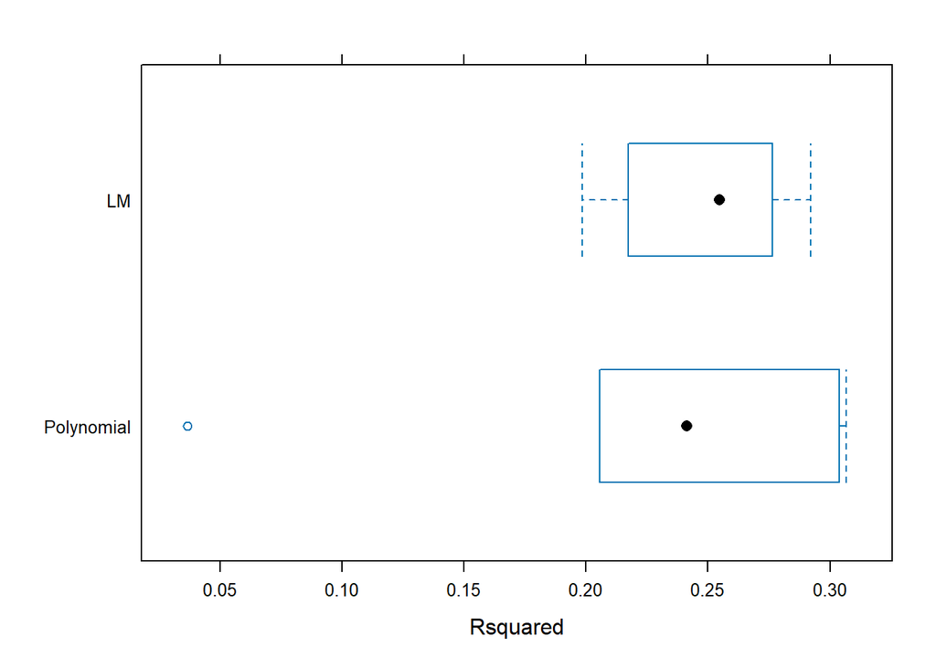

```r
bwplot(res, metric = "Rsquared") # higher = better
```

In the first plot (RMSE), lower values indicate better predictive performance. The linear model has a slightly lower average RMSE than the polynomial model. This means that, when predicting unseen data, the linear model produces slightly smaller prediction errors.

In the second plot (R²), higher values indicate better explanatory power in the test folds. Again, the linear model shows a slightly higher average R² than the polynomial model. Thus, it explains slightly more of the variation in log prices in out-of-sample predictions.

The boxplots display the distribution of performance across the five folds. Both models perform relatively similarly, but the polynomial model shows somewhat more variability and does not deliver any consistent improvement.

Overall, there is no evidence that adding polynomial (nonlinear) terms improves predictive accuracy for unseen data. The simpler linear model performs at least as well — and slightly better — while being more stable and easier to interpret. Therefore, the linear model is preferred.

# 5 Conclusions

This analysis examined the role of Airbnb across Zurich’s neighbourhoods with the objective of supporting the City of Zurich in evaluating whether targeted regulation of short-term rentals may be appropriate.

Regarding RQ1 and RQ2, Airbnb listings are clearly concentrated in central neighbourhoods such as City, Lindenhof, Enge, Langstrasse, and Werd. These areas show both high listing density and higher prices. However, Airbnb is also present in peripheral neighbourhoods where hotel infrastructure is limited. This suggests that Airbnb partly complements the traditional accommodation sector in underserved areas, while in central districts it may compete more directly with hotels and potentially intensify housing pressure.

With respect to RQ3, the distribution of listings per host indicates that the majority of hosts operate only one listing. This suggests that Zurich’s Airbnb market is still largely driven by individual hosts. Nevertheless, a smaller group of multi-listing hosts contributes disproportionately to total supply, indicating the presence of more commercial activity in certain areas.

Concerning RQ4, the vast majority of listings require very short minimum stays (1–2 nights), and availability varies substantially across listings. This indicates a strong short-term rental orientation, especially in central neighbourhoods. Areas with high availability and multiple listings per host may therefore be more exposed to regulatory measures such as annual rental caps.

In terms of RQ5, guest satisfaction appears consistently high. The proportion of negative reviews remains very low across all neighbourhoods (generally below 2.5%), and sentiment analysis confirms that reviews are overwhelmingly positive. There is strong evidence that more positive review sentiment is associated with higher prices, indicating that quality and reputation matter in Zurich’s Airbnb market.

Overall, the results suggest that Airbnb in Zurich is not a uniform phenomenon. In central neighbourhoods with high listing density and strong price premiums, short-term rentals may exert more pressure on the housing market and could be priority areas for regulatory attention. In contrast, in peripheral neighbourhoods with limited hotel presence, Airbnb may expand accommodation capacity without comparable housing displacement effects.

For the City of Zurich, this implies that broad, city-wide regulation may be less effective than targeted, neighbourhood-specific measures that account for listing concentration, host behaviour, and rental intensity.

# 6 Potential Limitations

Static pricing information: The dataset contains only one price per listing, although Airbnb prices are dynamic and may vary over time depending on demand, seasonality, and availability. Therefore, the observed price may not fully reflect actual pricing strategies throughout the year.

Limited property characteristics: The dataset does not provide detailed information on property size, number of rooms, number of beds, capacity (number of guests), or number of bathrooms. These factors are likely important determinants of price and may lead to omitted variable bias in the regression analysis.

Simplified sentiment analysis: Sentiment was measured using a basic lexicon-based approach (Bing dictionary). This method does not account for context, negation, or sarcasm. For example, phrases such as “not good” may be incorrectly classified as positive due to the presence of the word “good,” ignoring the negation.

Exclusion of non-English reviews: Non-English comments were removed prior to sentiment analysis. As a result, reviews written in German, Swiss German, or other languages are not included, which may bias the sentiment measure and limit representativeness.

# 7 Use of GenAI

**Tools used**

- ChatGPT
- Gemini

**What have you used it for?**

One of our main goals in this project was to use as little GenAI as possible in order to maximize our learning experience. We realized that in the previous semester we relied too heavily on such tools and did not achieve the learning progress we had hoped for. Therefore, we consciously decided to work independently and solve most problems ourselves.

Our main resources were the slides from the ILIAS Introduction to R course and the materials provided during the Bootcamp. Additionally, we created a dedicated project space within the GenAI tools to keep our work organized. We uploaded the course slides to these tools so that, whenever we had doubts or wanted to verify our approach, the responses would be aligned with the concepts covered in class.

GenAI was particularly helpful in explaining concepts that we did not fully understand. Rather than using it to generate complete solutions, we mainly used it as a supportive learning tool.

Another important use was improving the structure and clarity of our written analysis. We first drafted our ideas in our own English and then used GenAI to correct grammar, improve wording, and adjust the tone to better address our client.

**For what kind of tasks turned they out to be helpful?**

- Correcting language, grammar, and writing style
- Structuring and refining our analysis in a clearer and more professional way
- Supporting more advanced R functions or improving visual aspects of graphs (e.g., formatting or color adjustments)

**How do you check correctness of the answer?**

We verified the correctness of GenAI outputs primarily by running the suggested code and evaluating whether the results were reasonable. In addition, we compared explanations and approaches with the course slides and relevant cheat sheets.

By critically reviewing both the logic and the results, we ensured that we fully understood the solutions before incorporating them into our project.

**What did not work?**

Since we used GenAI selectively and always provided clear context and our own preliminary work, the tools generally worked well. We did not encounter major issues. However, we consistently evaluated the responses critically to ensure correctness and maintain academic integrity.

# 8 Appendix

## 8.1 Interactive map with all listings

```r
airbnb_listings <- d.merged %>%
  distinct(id, .keep_all = TRUE)

# Check that lat/lon look ok (optional)
summary(airbnb_listings$latitude)
```

```
##    Min. 1st Qu.  Median    Mean 3rd Qu.    Max.
##   47.32   47.37   47.38   47.38   47.39   47.43
```

```r
summary(airbnb_listings$longitude)
```

```
##    Min. 1st Qu.  Median    Mean 3rd Qu.    Max.
##   8.473   8.518   8.533   8.533   8.548   8.606
```

```r
# Basic leaflet map with basemap + all points
leaflet(airbnb_listings) %>%
  # tile layer with streets etc.
  addProviderTiles(providers$CartoDB.Positron) %>%

  # each Airbnb as a point with information
  addCircleMarkers(
    lng = ~longitude,
    lat = ~latitude,
    radius = 6,
    stroke = FALSE,
    fillOpacity = 0.6,
    color = "#FF5733",
    clusterOptions = markerClusterOptions(),
    popup = ~paste0(
      "<b>", name, "</b><br/>",
      "Room type: ", room_type, "<br/>",
      "Price: ", price, " CHF<br/>",
      "Neighbourhood: ", neighbourhood
    )
  )
```

[interactive chart not shown]